# Preparación de datos - Socialización de la meritocracia

Castillo, J.C., Iturra, J., Meneses, F. & Venegas, M.

2021-07-02

# Introducción

El presente documento tiene por finalidad la preparación de datos del artículo en proceso “La socialización de la meritocracia: el rol de la familia y la escuela” a cargo de Juan Carlos Castillo. El artículo se desarrolla en el marco del proyecto FONDECYT Regular N°1181239: “Socialización política y educación para la ciudadanía: el rol de la familia y de la escuela.” que cuenta con Cristian Cox como investigador principal.

La estructura para la preparación consistirá en cinco partes. La primera corresponde a cargar las librerías de R para la elaboración del documento. En la segunda se cargarán las bases de datos, información generada desde el proyoecto. En la tercera se seleccionarán las variables a utilizar. En la cuarta, dónde estará el grueso del documento, se procesarán las variables. El procesamiento se divirá en torno a variables relacionadas a apoderados y a estudiantes. Para ambas, se seguirá el siguiente orden: descriptivo, recodificación, etiquetado, descriptivo post-rec y otros ajustes. Además, al lado de cada variable figurará un entreparentesis indicando si corresponde a una variable independiente (Var. Indep.), dependiente (Var. Dep.) o un control (Control) de nivel uno (N1) o dos (N2) Por último, se generará una base de datos procesada para los análisis posteriores, en conjunto a una tabla de descriptivos para la base completa.

# Resumen ejecutivo:

Se listan los puntos mas importantes:

## Registro para revisar

- Para la variable de promedios (obtenido y merecido) existían datos menores a 1 y mayores a 7. En detalle, existían 6 casos para el promedio obtenido y 12 casos para el promedio merecido que no se ajustan a la escala. Provisoriamente fueron recodificados a NA.
- Para la variable de año de nacimiento del apoderado existían datos poco probables. En detalle, existían 10 casos que indican años mayores a 1992. Provisoriamente fueron recodificados a NA.
- Variables de nivel 2 (ingresos por escuela, educación terciaria por escuela y heterogeneidad) cuentan con demasiados NA. Revisar código.
- Dos cosas importantes sobre la variable ingresos. La primera es que existen 148 casos correspondientes a NS/NR que han sido recodificados a NA, discutir mantener categoría. La segunda es que en ingresos nivel dos solo existen 7 NA, pertenecientes a los RBD 10452 (solo contestaron estudiantes) y 31047 (ninguno de los seis apoderados de este colegio reportaron sus ingresos).

## Registro de cambios principales:

- Cambio presentación de las variables. Se dividen entre variables estudiantes y apoderados.
- Se modifica la introducción en función del cambio de estructura.
- Cambio etiquetas variables percepción meritocracia. Se asignan etiquetas más intuitivas para los indicadores.
- Se agrega código de frecuencias posterior a la recodificación por cada variable.
- Se añade tabla descriptiva general, la cual incluye NA’s.
- Se arregla construcción de ingreso del hogar. Faltaba una categoría por codificar.
- Se recodifican los valores 8 y 9 en Ns/Nr para las variables de posición política.
- Se desactiva indice flotante ya que choca con la tabla de summarytools.
- Se agregan variables para nueva propuesta
- Se arregla caso mal pareado (897 estudiante). Era un error de tipeo, aunque no cambia el N.
- Se crean variables promedios de percepción meritocrática (en estudiantes y apoderados)
- Se incorpora código detallado sobre nivel educacional (código grupo Tolerancia adaptado)
- Se crean variables factor con su respectivo etiquetado.
- Se centran las variables a utilizar en los modelos (CWC)

# Procesamiento

## Parte 1: Cargar librerías

Las librerías a utilizar para la elaboración del documento serán:

- *dplyr:* ajuste general de datos
- *sjmisc:* descripción y exploración de base de datos
- *car:* principalmente la función recode para recodificar/agrupar valores de variable
- *stargazer:* para tabla descriptiva
- *haven:* leer archivos .dta
- *SciViews:* cálculos básicos de matemáticas
- *summarytools:* tablas descriptivas
- *misty* funciones miscelaneas

```r
pacman::p_load(dplyr, sjmisc, car, sjlabelled, stargazer, SciViews, summarytools, misty,ggplot2)
```

## Parte 2: Cargar datos

```r
# Bases de apoderados.
ap <- haven::read_dta("https://github.com/formacionciudadana/data-paces/raw/main/docs/paces/data/base_apoderadosv2.dta")

# Base de estudiantes.
est <- haven::read_dta("https://github.com/formacionciudadana/data-paces/raw/main/docs/paces/data/base_estudiantesv2.dta")

# Arreglar caso 897
ap$FOLIO_EST[ap$FOLIO_EST == 897] <- 892
```

Cabe señalar que dentro de la base de datos existe un caso mal pareado (relación folio estudiante-apoderado). Esto se arregla cambiando el folio erroneo (897 del apoderaod) por su correspondiente.

## Parte 3: Seleccionar variables

```r
# Seleccionar  y renombrar variables de la base de datos de apoderados
ap_proc <- ap %>% dplyr::select(rbd = RBD,
                                folio = FOLIO_EST,
                               region = REGION,
                               dependencia = Dependencia,
                               pos_pol = P23,
                               genero = P39,
                               nacimiento = P40A,
                               personas_hogar = P41,
                               educ_ac = P45,
                               ingresos_tramos = P55,
                               libros_hogar = P47,
                               perc_trabajo_duro = P9D,
                               perc_esfuerzo = P10D,
                               recompensa = P10C,
                               atriv_pobr_esf = P11C,
                               atriv_pobr_tal = P11A,
                               juicio_desigualdad = P10A,
                               redistriv = P10B,
                               educ = P10E,
                               salud = P10F)

# Seleccionar y renombrar variables de la base de datos de estudiantes.
est_proc <- est  %>% dplyr::select(rbd = RBD,
                                 region = REGION,
                                 folio = FOLIO,
                                 dependencia = Dependencia,
                                 pos_pol = P59,
                                 genero = P58,
                                 resp_prof = P56B,
                                 educ_padre = P66,
                                 educ_madre = P67,
                                 libros_hogar = P68,
                                 perc_trabajo_duro = P24D,
                                 perc_esfuerzo = P25D,
                                 prom_obt = P27,
                                 prom_mer = P28,
                                 sj_direct = P29,
                                 recompensa = P25C,
                                 tiempo_compartido = P36,
                                 educ= P25E,
                                 salud= P25F,
                                 juicio_desigualdad = P25A,
                                 atriv_pobr_esf = P26C,
                                 atriv_pobr_tal =P26A,
                                 redistriv =P25B,
                                 cortes = P35B,
                                 tomas= P35C)
```

## Parte 4: Procesamiento

### Variables estudiantes

#### Percepción meritocratica estudiantes: Importancia trabajo duro (Var. Dep. N1)

##### Descriptivo

```r
frq(est_proc$perc_trabajo_duro) # Frecuencias
```

```
##
## P24D Actualmente en Chile, para surgir en la vida ¿Cuán importante esEL TRABAJO  (x) <numeric>
## # total N=1635  valid N=1635  mean=3.52  sd=1.26
##
## Value |                      Label |   N | Raw % | Valid % | Cum. %
## -------------------------------------------------------------------
##     1 |            Nada importante |  69 |  4.22 |    4.22 |   4.22
##     2 |            Algo importante | 194 | 11.87 |   11.87 |  16.09
##     3 |                 Importante | 413 | 25.26 |   25.26 |  41.35
##     4 |             Muy importante | 912 | 55.78 |   55.78 |  97.13
##     5 | Marca mas de 1 alternativa |   1 |  0.06 |    0.06 |  97.19
##     9 |                         Nr |  46 |  2.81 |    2.81 | 100.00
##  <NA> |                       <NA> |   0 |  0.00 |    <NA> |   <NA>
```

```r
table(est_proc$perc_trabajo_duro)
```

```
##
##   1   2   3   4   5   9
##  69 194 413 912   1  46
```

##### Recodificación

Se recodifica a NA las categorías 5 y 9, correspondiente a las etiquetas “Marca más de 1 alternativa” y “Nr”.

```r
est_proc$perc_trabajo_duro <- set_na(est_proc$perc_trabajo_duro, na = c(5,9), drop.levels = TRUE, as.tag = FALSE) # Transformar a NA
```

##### Etiquetado

```r
est_proc$perc_trabajo_duro <- set_label(x = est_proc$perc_trabajo_duro,label = "Percepcion meritocracia: Importancia trabajo duro estudiantes") # Etiquetar
```

##### Descriptivo post-rec

```r
frq(est_proc$perc_trabajo_duro) # Frecuencias post recodificación
```

```
##
## Percepcion meritocracia: Importancia trabajo duro estudiantes (x) <numeric>
## # total N=1635  valid N=1588  mean=3.37  sd=0.86
##
## Value |           Label |   N | Raw % | Valid % | Cum. %
## --------------------------------------------------------
##     1 | Nada importante |  69 |  4.22 |    4.35 |   4.35
##     2 | Algo importante | 194 | 11.87 |   12.22 |  16.56
##     3 |      Importante | 413 | 25.26 |   26.01 |  42.57
##     4 |  Muy importante | 912 | 55.78 |   57.43 | 100.00
##  <NA> |            <NA> |  47 |  2.87 |    <NA> |   <NA>
```

##### Otros ajustes

No aplica.

#### Percepción meritocratica estudiantes: Esfuerzo para salir adelante (Var. Dep. N1)

##### Descriptivo

```r
frq(est_proc$perc_esfuerzo)
```

```
##
## P25D ¿Cuán de acuerdo o en desacuerdo estás con las siguientes afirmaciones?EN C (x) <numeric>
## # total N=1635  valid N=1635  mean=3.38  sd=1.38
##
## Value |                      Label |   N | Raw % | Valid % | Cum. %
## -------------------------------------------------------------------
##     1 |          Muy en desacuerdo |  59 |  3.61 |    3.61 |   3.61
##     2 |              En desacuerdo | 227 | 13.88 |   13.88 |  17.49
##     3 |                 De acuerdo | 700 | 42.81 |   42.81 |  60.31
##     4 |             Muy de acuerdo | 582 | 35.60 |   35.60 |  95.90
##     5 | Marca mas de 1 alternativa |   3 |  0.18 |    0.18 |  96.09
##     9 |                         Nr |  64 |  3.91 |    3.91 | 100.00
##  <NA> |                       <NA> |   0 |  0.00 |    <NA> |   <NA>
```

##### Recodificación

Se recodifica a NA las categorías 5 y 9, correspondiente a las etiquetas “Marca más de 1 alternativa” y “Nr”.

```r
est_proc$perc_esfuerzo <- set_na(est_proc$perc_esfuerzo, na = c(5,9), drop.levels = TRUE, as.tag = FALSE)
```

##### Etiquetado

```r
est_proc$perc_esfuerzo <- set_label(x = est_proc$perc_esfuerzo, label = "Percepcion meritocracia: Esfuerzo para salir adelante estudiantes")
```

##### Descriptivo post-rec

```r
frq(est_proc$perc_esfuerzo)
```

```
##
## Percepcion meritocracia: Esfuerzo para salir adelante estudiantes (x) <numeric>
## # total N=1635  valid N=1568  mean=3.15  sd=0.80
##
## Value |             Label |   N | Raw % | Valid % | Cum. %
## ----------------------------------------------------------
##     1 | Muy en desacuerdo |  59 |  3.61 |    3.76 |   3.76
##     2 |     En desacuerdo | 227 | 13.88 |   14.48 |  18.24
##     3 |        De acuerdo | 700 | 42.81 |   44.64 |  62.88
##     4 |    Muy de acuerdo | 582 | 35.60 |   37.12 | 100.00
##  <NA> |              <NA> |  67 |  4.10 |    <NA> |   <NA>
```

##### Otros ajustes

Creación variable: promedio de percepción de meritocracia en estudiantes

```r
# Crear variable
est_proc$prom_percmer_est <- ((est_proc$perc_trabajo_duro + est_proc$perc_esfuerzo)/2)

# Etiquetar
est_proc$prom_percmer_est <- set_label(x = est_proc$prom_percmer_est, label = "Promedio percepcion meritocratica estudiantes")
```

Creación variables factores

```r
# Esfuerzo
est_proc$perc_esfuerzo_factor <- factor(est_proc$perc_esfuerzo, levels = c(1,2,3,4), labels = c("Muy en desacuerdo", "En desacuerdo", "De acuerdo", "Muy de acuerdo"))

# Etiquetar
est_proc$perc_esfuerzo_factor <- set_label(x = est_proc$perc_esfuerzo_factor, label = "Percepcion meritocracia: Esfuerzo para salir adelante estudiantes")


# Trabajo duro
est_proc$perc_trabajo_duro_factor <- factor(est_proc$perc_trabajo_duro, levels = c(1,2,3,4), labels = c("Nada importante", "Algo importante", "Importante", "Muy importante"))

# Etiquetar
est_proc$perc_trabajo_duro_factor <- set_label(x = est_proc$perc_trabajo_duro_factor, label = "Percepcion meritocracia: Importancia trabajo duro estudiantes factor")
```

#### Sentido de justicia (indirecto): Promedio obtenido y merecido (Var. Indep. N1)

##### Descriptivo

```r
# Promedio obtenido
summary(est_proc$prom_obt) # Descriptivo
```

```
##    Min. 1st Qu.  Median    Mean 3rd Qu.    Max.
##    1.00    5.40    5.90   13.18    6.30   99.00
```

```r
frq(est_proc$prom_obt)
```

```
##
## P27 ¿Qué promedio de nota obtuviste el año pasado? Si no lo recuerdas exactament (x) <numeric>
## # total N=1635  valid N=1635  mean=13.18  sd=25.24
##
## Value | Label |   N | Raw % | Valid % | Cum. %
## ----------------------------------------------
##  1.00 |     1 |   1 |  0.06 |    0.06 |   0.06
##  1.10 |   1.1 |   1 |  0.06 |    0.06 |   0.12
##  2.00 |     2 |   1 |  0.06 |    0.06 |   0.18
##  2.90 |   2.9 |   1 |  0.06 |    0.06 |   0.24
##  3.00 |     3 |   1 |  0.06 |    0.06 |   0.31
##  3.50 |   3.5 |   1 |  0.06 |    0.06 |   0.37
##  3.60 |   3.6 |   2 |  0.12 |    0.12 |   0.49
##  3.80 |   3.8 |   1 |  0.06 |    0.06 |   0.55
##  3.90 |   3.9 |   1 |  0.06 |    0.06 |   0.61
##  4.00 |     4 |   3 |  0.18 |    0.18 |   0.80
##  4.10 |   4.1 |   3 |  0.18 |    0.18 |   0.98
##  4.20 |   4.2 |   2 |  0.12 |    0.12 |   1.10
##  4.30 |   4.3 |   7 |  0.43 |    0.43 |   1.53
##  4.40 |   4.4 |   4 |  0.24 |    0.24 |   1.77
##  4.50 |   4.5 |  18 |  1.10 |    1.10 |   2.87
##  4.60 |   4.6 |  12 |  0.73 |    0.73 |   3.61
##  4.70 |   4.7 |  15 |  0.92 |    0.92 |   4.53
##  4.80 |   4.8 |  23 |  1.41 |    1.41 |   5.93
##  4.90 |   4.9 |  26 |  1.59 |    1.59 |   7.52
##  5.00 |     5 |  87 |  5.32 |    5.32 |  12.84
##  5.10 |   5.1 |  41 |  2.51 |    2.51 |  15.35
##  5.20 |   5.2 |  56 |  3.43 |    3.43 |  18.78
##  5.30 |   5.3 |  60 |  3.67 |    3.67 |  22.45
##  5.40 |   5.4 |  74 |  4.53 |    4.53 |  26.97
##  5.50 |   5.5 |  96 |  5.87 |    5.87 |  32.84
##  5.60 |   5.6 |  74 |  4.53 |    4.53 |  37.37
##  5.70 |   5.7 |  87 |  5.32 |    5.32 |  42.69
##  5.80 |   5.8 | 105 |  6.42 |    6.42 |  49.11
##  5.90 |   5.9 |  99 |  6.06 |    6.06 |  55.17
##  6.00 |     6 | 105 |  6.42 |    6.42 |  61.59
##  6.10 |   6.1 |  92 |  5.63 |    5.63 |  67.22
##  6.20 |   6.2 |  76 |  4.65 |    4.65 |  71.87
##  6.30 |   6.3 |  84 |  5.14 |    5.14 |  77.00
##  6.40 |   6.4 |  56 |  3.43 |    3.43 |  80.43
##  6.50 |   6.5 |  58 |  3.55 |    3.55 |  83.98
##  6.60 |   6.6 |  40 |  2.45 |    2.45 |  86.42
##  6.70 |   6.7 |  37 |  2.26 |    2.26 |  88.69
##  6.80 |   6.8 |  32 |  1.96 |    1.96 |  90.64
##  6.90 |   6.9 |  12 |  0.73 |    0.73 |  91.38
##  7.00 |     7 |   5 |  0.31 |    0.31 |  91.68
##  7.10 |   7.1 |   1 |  0.06 |    0.06 |  91.74
##  8.50 |   8.5 |   1 |  0.06 |    0.06 |  91.80
## 10.00 |    10 |   2 |  0.12 |    0.12 |  91.93
## 15.00 |    15 |   2 |  0.12 |    0.12 |  92.05
## 99.00 |    Nr | 130 |  7.95 |    7.95 | 100.00
##  <NA> |  <NA> |   0 |  0.00 |    <NA> |   <NA>
```

```r
# Promedio merecido
summary(est_proc$prom_mer)
```

```
##    Min. 1st Qu.  Median    Mean 3rd Qu.    Max.
##    0.00    5.70    6.00   14.75    6.60   99.00
```

```r
frq(est_proc$prom_mer)
```

```
##
## P28 Y, ¿Qué promedio de nota piensas que merecías? (x) <numeric>
## # total N=1635  valid N=1635  mean=14.75  sd=27.17
##
## Value | Label |   N | Raw % | Valid % | Cum. %
## ----------------------------------------------
##  0.00 |     0 |   1 |  0.06 |    0.06 |   0.06
##  1.00 |     1 |   1 |  0.06 |    0.06 |   0.12
##  1.60 |   1.6 |   1 |  0.06 |    0.06 |   0.18
##  2.00 |     2 |   6 |  0.37 |    0.37 |   0.55
##  3.00 |     3 |   5 |  0.31 |    0.31 |   0.86
##  4.00 |     4 |  13 |  0.80 |    0.80 |   1.65
##  4.20 |   4.2 |   2 |  0.12 |    0.12 |   1.77
##  4.30 |   4.3 |   2 |  0.12 |    0.12 |   1.90
##  4.40 |   4.4 |   2 |  0.12 |    0.12 |   2.02
##  4.50 |   4.5 |  16 |  0.98 |    0.98 |   3.00
##  4.60 |   4.6 |   4 |  0.24 |    0.24 |   3.24
##  4.70 |   4.7 |   5 |  0.31 |    0.31 |   3.55
##  4.80 |   4.8 |   5 |  0.31 |    0.31 |   3.85
##  4.90 |   4.9 |  11 |  0.67 |    0.67 |   4.53
##  5.00 |     5 |  83 |  5.08 |    5.08 |   9.60
##  5.10 |   5.1 |  10 |  0.61 |    0.61 |  10.21
##  5.20 |   5.2 |  17 |  1.04 |    1.04 |  11.25
##  5.30 |   5.3 |  21 |  1.28 |    1.28 |  12.54
##  5.40 |   5.4 |  29 |  1.77 |    1.77 |  14.31
##  5.50 |   5.5 | 102 |  6.24 |    6.24 |  20.55
##  5.60 |   5.6 |  40 |  2.45 |    2.45 |  23.00
##  5.70 |   5.7 |  41 |  2.51 |    2.51 |  25.50
##  5.80 |   5.8 |  72 |  4.40 |    4.40 |  29.91
##  5.90 |   5.9 |  52 |  3.18 |    3.18 |  33.09
##  6.00 |     6 | 302 | 18.47 |   18.47 |  51.56
##  6.10 |   6.1 |  45 |  2.75 |    2.75 |  54.31
##  6.20 |   6.2 |  69 |  4.22 |    4.22 |  58.53
##  6.30 |   6.3 |  73 |  4.46 |    4.46 |  63.00
##  6.40 |   6.4 |  52 |  3.18 |    3.18 |  66.18
##  6.50 |   6.5 | 137 |  8.38 |    8.38 |  74.56
##  6.60 |   6.6 |  45 |  2.75 |    2.75 |  77.31
##  6.70 |   6.7 |  41 |  2.51 |    2.51 |  79.82
##  6.80 |   6.8 |  55 |  3.36 |    3.36 |  83.18
##  6.90 |   6.9 |  20 |  1.22 |    1.22 |  84.40
##  7.00 |     7 |  91 |  5.57 |    5.57 |  89.97
##  7.20 |   7.2 |   1 |  0.06 |    0.06 |  90.03
##  7.80 |   7.8 |   2 |  0.12 |    0.12 |  90.15
##  8.00 |     8 |   3 |  0.18 |    0.18 |  90.34
##  9.00 |     9 |   1 |  0.06 |    0.06 |  90.40
## 10.00 |    10 |   1 |  0.06 |    0.06 |  90.46
## 15.00 |    15 |   2 |  0.12 |    0.12 |  90.58
## 90.00 |    90 |   1 |  0.06 |    0.06 |  90.64
## 99.00 |    Nr | 153 |  9.36 |    9.36 | 100.00
##  <NA> |  <NA> |   0 |  0.00 |    <NA> |   <NA>
```

##### Recodificación

Se recodifica a NA las siguientes situaciones: - Datos 99, correspondiente a No responde. - Datos menores a 1 - Datos mayores a 7

```r
# Promedio obtenido
est_proc$prom_obt[est_proc$prom_obt == 99] <- NA
est_proc$prom_obt[est_proc$prom_obt < 1 | est_proc$prom_obt > 7] <- NA

# Promedio merecido
est_proc$prom_mer[est_proc$prom_mer == 99] <- NA
est_proc$prom_mer[est_proc$prom_mer < 1 | est_proc$prom_mer > 7] <- NA
```

##### Etiquetado

```r
# Promedio obtenido
est_proc$prom_obt <- set_label(x = est_proc$prom_obt, label = "Promedio de notas obtenido")

# Promedio merecido
est_proc$prom_mer <- set_label(x = est_proc$prom_mer, label = "Promedio de notas merecido")
```

##### Descriptivio post-rec

```r
# Promedio obtenido
summary(est_proc$prom_obt) # Descriptivo
```

```
##    Min. 1st Qu.  Median    Mean 3rd Qu.    Max.    NA's
##   1.000   5.400   5.800   5.745   6.200   7.000     136
```

```r
frq(est_proc$prom_obt)
```

```
##
## Promedio de notas obtenido (x) <numeric>
## # total N=1635  valid N=1499  mean=5.75  sd=0.63
##
## Value | Label |   N | Raw % | Valid % | Cum. %
## ----------------------------------------------
##  1.00 |     1 |   1 |  0.06 |    0.07 |   0.07
##  1.10 |   1.1 |   1 |  0.06 |    0.07 |   0.13
##  2.00 |     2 |   1 |  0.06 |    0.07 |   0.20
##  2.90 |   2.9 |   1 |  0.06 |    0.07 |   0.27
##  3.00 |     3 |   1 |  0.06 |    0.07 |   0.33
##  3.50 |   3.5 |   1 |  0.06 |    0.07 |   0.40
##  3.60 |   3.6 |   2 |  0.12 |    0.13 |   0.53
##  3.80 |   3.8 |   1 |  0.06 |    0.07 |   0.60
##  3.90 |   3.9 |   1 |  0.06 |    0.07 |   0.67
##  4.00 |     4 |   3 |  0.18 |    0.20 |   0.87
##  4.10 |   4.1 |   3 |  0.18 |    0.20 |   1.07
##  4.20 |   4.2 |   2 |  0.12 |    0.13 |   1.20
##  4.30 |   4.3 |   7 |  0.43 |    0.47 |   1.67
##  4.40 |   4.4 |   4 |  0.24 |    0.27 |   1.93
##  4.50 |   4.5 |  18 |  1.10 |    1.20 |   3.14
##  4.60 |   4.6 |  12 |  0.73 |    0.80 |   3.94
##  4.70 |   4.7 |  15 |  0.92 |    1.00 |   4.94
##  4.80 |   4.8 |  23 |  1.41 |    1.53 |   6.47
##  4.90 |   4.9 |  26 |  1.59 |    1.73 |   8.21
##  5.00 |     5 |  87 |  5.32 |    5.80 |  14.01
##  5.10 |   5.1 |  41 |  2.51 |    2.74 |  16.74
##  5.20 |   5.2 |  56 |  3.43 |    3.74 |  20.48
##  5.30 |   5.3 |  60 |  3.67 |    4.00 |  24.48
##  5.40 |   5.4 |  74 |  4.53 |    4.94 |  29.42
##  5.50 |   5.5 |  96 |  5.87 |    6.40 |  35.82
##  5.60 |   5.6 |  74 |  4.53 |    4.94 |  40.76
##  5.70 |   5.7 |  87 |  5.32 |    5.80 |  46.56
##  5.80 |   5.8 | 105 |  6.42 |    7.00 |  53.57
##  5.90 |   5.9 |  99 |  6.06 |    6.60 |  60.17
##  6.00 |     6 | 105 |  6.42 |    7.00 |  67.18
##  6.10 |   6.1 |  92 |  5.63 |    6.14 |  73.32
##  6.20 |   6.2 |  76 |  4.65 |    5.07 |  78.39
##  6.30 |   6.3 |  84 |  5.14 |    5.60 |  83.99
##  6.40 |   6.4 |  56 |  3.43 |    3.74 |  87.73
##  6.50 |   6.5 |  58 |  3.55 |    3.87 |  91.59
##  6.60 |   6.6 |  40 |  2.45 |    2.67 |  94.26
##  6.70 |   6.7 |  37 |  2.26 |    2.47 |  96.73
##  6.80 |   6.8 |  32 |  1.96 |    2.13 |  98.87
##  6.90 |   6.9 |  12 |  0.73 |    0.80 |  99.67
##  7.00 |     7 |   5 |  0.31 |    0.33 | 100.00
## 99.00 |    Nr |   0 |  0.00 |    0.00 | 100.00
##  <NA> |  <NA> | 136 |  8.32 |    <NA> |   <NA>
```

```r
# Promedio merecido
summary(est_proc$prom_mer)
```

```
##    Min. 1st Qu.  Median    Mean 3rd Qu.    Max.    NA's
##   1.000   5.600   6.000   5.975   6.500   7.000     165
```

```r
frq(est_proc$prom_mer)
```

```
##
## Promedio de notas merecido (x) <numeric>
## # total N=1635  valid N=1470  mean=5.97  sd=0.70
##
## Value | Label |   N | Raw % | Valid % | Cum. %
## ----------------------------------------------
##  1.00 |     1 |   1 |  0.06 |    0.07 |   0.07
##  1.60 |   1.6 |   1 |  0.06 |    0.07 |   0.14
##  2.00 |     2 |   6 |  0.37 |    0.41 |   0.54
##  3.00 |     3 |   5 |  0.31 |    0.34 |   0.88
##  4.00 |     4 |  13 |  0.80 |    0.88 |   1.77
##  4.20 |   4.2 |   2 |  0.12 |    0.14 |   1.90
##  4.30 |   4.3 |   2 |  0.12 |    0.14 |   2.04
##  4.40 |   4.4 |   2 |  0.12 |    0.14 |   2.18
##  4.50 |   4.5 |  16 |  0.98 |    1.09 |   3.27
##  4.60 |   4.6 |   4 |  0.24 |    0.27 |   3.54
##  4.70 |   4.7 |   5 |  0.31 |    0.34 |   3.88
##  4.80 |   4.8 |   5 |  0.31 |    0.34 |   4.22
##  4.90 |   4.9 |  11 |  0.67 |    0.75 |   4.97
##  5.00 |     5 |  83 |  5.08 |    5.65 |  10.61
##  5.10 |   5.1 |  10 |  0.61 |    0.68 |  11.29
##  5.20 |   5.2 |  17 |  1.04 |    1.16 |  12.45
##  5.30 |   5.3 |  21 |  1.28 |    1.43 |  13.88
##  5.40 |   5.4 |  29 |  1.77 |    1.97 |  15.85
##  5.50 |   5.5 | 102 |  6.24 |    6.94 |  22.79
##  5.60 |   5.6 |  40 |  2.45 |    2.72 |  25.51
##  5.70 |   5.7 |  41 |  2.51 |    2.79 |  28.30
##  5.80 |   5.8 |  72 |  4.40 |    4.90 |  33.20
##  5.90 |   5.9 |  52 |  3.18 |    3.54 |  36.73
##  6.00 |     6 | 302 | 18.47 |   20.54 |  57.28
##  6.10 |   6.1 |  45 |  2.75 |    3.06 |  60.34
##  6.20 |   6.2 |  69 |  4.22 |    4.69 |  65.03
##  6.30 |   6.3 |  73 |  4.46 |    4.97 |  70.00
##  6.40 |   6.4 |  52 |  3.18 |    3.54 |  73.54
##  6.50 |   6.5 | 137 |  8.38 |    9.32 |  82.86
##  6.60 |   6.6 |  45 |  2.75 |    3.06 |  85.92
##  6.70 |   6.7 |  41 |  2.51 |    2.79 |  88.71
##  6.80 |   6.8 |  55 |  3.36 |    3.74 |  92.45
##  6.90 |   6.9 |  20 |  1.22 |    1.36 |  93.81
##  7.00 |     7 |  91 |  5.57 |    6.19 | 100.00
## 99.00 |    Nr |   0 |  0.00 |    0.00 | 100.00
##  <NA> |  <NA> | 165 | 10.09 |    <NA> |   <NA>
```

##### Otros ajustes

Se elaboran dos variables nuevas a partir del cálculo para evaluación de justicia de Jasso (1980). La primera corresponde al logaritmo natural de la proporción entre el promedio obtenido y el promedio merecido. La segunda corresponde a la misma proporción sin el logaritmo.

```r
# Cálculo sentido justicia original
est_proc$sj_indirect_ln <-  ln(est_proc$prom_obt/est_proc$prom_mer)

# Cálculo sentido justicia sin ln
est_proc$sj_indirect_noln <-  est_proc$prom_obt/est_proc$prom_mer

##### ---- Descriptivos variables nuevas ----
# Sentido de justicia
summary(est_proc$sj_indirect_ln)
```

```
##     Min.  1st Qu.   Median     Mean  3rd Qu.     Max.     NA's
## -0.88120 -0.06899 -0.03226 -0.03773  0.00000  1.06471      171
```

```r
# Sentido de justicia sin ln
summary(est_proc$sj_indirect_noln)
```

```
##    Min. 1st Qu.  Median    Mean 3rd Qu.    Max.    NA's
##  0.4143  0.9333  0.9683  0.9692  1.0000  2.9000     171
```

```r
##### ---- Etiquetado varibles nuevas ----
# Sentido de justicia
est_proc$sj_indirect_ln <- set_label(x = est_proc$sj_indirect_ln, label = "Sentido de justicia indirecto")

# Sentido de justicia sin ln
est_proc$sj_indirect_noln <- set_label(x = est_proc$sj_indirect_ln, label = "Sentido de justicia indirecto SIN LN")
```

#### Sentido de justicia (directo) (Var. Indep. N1)

##### Descriptivo

```r
frq(est_proc$sj_direct)
```

```
##
## P29 Tomando en cuenta el tiempo que le dedico a mis estudios, las notas que me s (x) <numeric>
## # total N=1635  valid N=1635  mean=2.28  sd=1.64
##
## Value |                      Label |   N | Raw % | Valid % | Cum. %
## -------------------------------------------------------------------
##     1 |   Menos de las que merezco | 349 | 21.35 |   21.35 |  21.35
##     2 |            Las que merezco | 978 | 59.82 |   59.82 |  81.16
##     3 |     Más de las que merezco | 214 | 13.09 |   13.09 |  94.25
##     4 | Marca mas de 1 alternativa |  14 |  0.86 |    0.86 |  95.11
##     9 |                         Nr |  80 |  4.89 |    4.89 | 100.00
##  <NA> |                       <NA> |   0 |  0.00 |    <NA> |   <NA>
```

##### Recodificación

Se transforma a NA los valores 4 y 9, correspondientes a las categorías “Marca mas de una alternativa” y “Nr”

```r
est_proc$sj_direct <- set_na(est_proc$sj_direct, na = c(4,9), drop.levels = TRUE, as.tag = FALSE)
```

##### Etiquetado

```r
est_proc$sj_direct <- set_label(x = est_proc$sj_direct, label = "Sentido de justicia directo")
```

##### Descriptivo post-rec

```r
frq(est_proc$sj_direct)
```

```
##
## Sentido de justicia directo (x) <numeric>
## # total N=1635  valid N=1541  mean=1.91  sd=0.60
##
## Value |                    Label |   N | Raw % | Valid % | Cum. %
## -----------------------------------------------------------------
##     1 | Menos de las que merezco | 349 | 21.35 |   22.65 |  22.65
##     2 |          Las que merezco | 978 | 59.82 |   63.47 |  86.11
##     3 |   Más de las que merezco | 214 | 13.09 |   13.89 | 100.00
##  <NA> |                     <NA> |  94 |  5.75 |    <NA> |   <NA>
```

##### Otros ajustes

Crear variable factor

```r
# Factor
est_proc$sj_direct_factor <- factor(est_proc$sj_direct, levels = c(1,2,3), labels = c("Menos de las que merezco", "Las que merezco", "Más de las que merezco"))

# Etiquetar
est_proc$sj_direct_factor <- set_label(x = est_proc$sj_direct_factor, label = "Sentido de justicia directo factor")
```

#### NSE: Educacion (Var. Indep. N1)

##### Descriptivo

```r
# Cuestionario estudiantes
frq(est_proc$educ_madre)
```

```
##
## P67 ¿Cuál es el último curso o nivel de estudios que alcanzó tu madre? (x) <numeric>
## # total N=1635  valid N=1635  mean=4.08  sd=2.00
##
## Value |                                                                        Label |   N | Raw % | Valid % | Cum. %
## ---------------------------------------------------------------------------------------------------------------------
##     1 |                                                       No completó 8vo Básico |  89 |  5.44 |    5.44 |   5.44
##     2 |                                                                   8vo básico | 118 |  7.22 |    7.22 |  12.66
##     3 |                                                              Educación media | 566 | 34.62 |   34.62 |  47.28
##     4 | Educación Técnica superior (Instituto profesional o Centro de Formación Técn | 367 | 22.45 |   22.45 |  69.72
##     5 |  Una carrera en la Universidad o estudios de posgrado (Magíster o Doctorado) | 314 | 19.20 |   19.20 |  88.93
##     8 |                                                   Marca mas de 1 alternativa |  14 |  0.86 |    0.86 |  89.79
##     9 |                                                                           Nr | 167 | 10.21 |   10.21 | 100.00
##  <NA> |                                                                         <NA> |   0 |  0.00 |    <NA> |   <NA>
```

```r
frq(est_proc$educ_padre)
```

```
##
## P66 ¿Cuál es el último curso o nivel de estudios que alcanzó tu padre? (x) <numeric>
## # total N=1635  valid N=1635  mean=4.23  sd=2.14
##
## Value |                                                                        Label |   N | Raw % | Valid % | Cum. %
## ---------------------------------------------------------------------------------------------------------------------
##     1 |                                                       No completó 8vo Básico |  87 |  5.32 |    5.32 |   5.32
##     2 |                                                                   8vo básico | 123 |  7.52 |    7.52 |  12.84
##     3 |                                                              Educación media | 541 | 33.09 |   33.09 |  45.93
##     4 | Educación Técnica superior (Instituto profesional o Centro de Formación Técn | 338 | 20.67 |   20.67 |  66.61
##     5 |  Una carrera en la Universidad o estudios de posgrado (Magíster o Doctorado) | 322 | 19.69 |   19.69 |  86.30
##     8 |                                                   Marca mas de 1 alternativa |  16 |  0.98 |    0.98 |  87.28
##     9 |                                                                           Nr | 208 | 12.72 |   12.72 | 100.00
##  <NA> |                                                                         <NA> |   0 |  0.00 |    <NA> |   <NA>
```

##### Recodificacion

Se transforma el valor 9 (Nr) y el 8 (Marca mas de 1 alternativa) en NA em ambas variables.

```r
# Cuestionario estudiantes
est_proc$educ_madre <- set_na(est_proc$educ_madre, na = c(8,9), drop.levels = TRUE, as.tag = FALSE)

est_proc$educ_padre <- set_na(est_proc$educ_padre, na = c(8,9), drop.levels = TRUE, as.tag = FALSE)
```

##### Etiquetado

```r
# Cuestionario estudiantes
est_proc$educ_madre <- set_label(x = est_proc$educ_madre, label = "Nivel educacional más alto de la madre")

est_proc$educ_padre <- set_label(x = est_proc$educ_padre, label = "Nivel educacional más alto del padre")
```

##### Descriptivo post-rec

```r
# Cuestionario estudiantes
frq(est_proc$educ_madre)
```

```
##
## Nivel educacional más alto de la madre (x) <numeric>
## # total N=1635  valid N=1454  mean=3.48  sd=1.10
##
## Value |                                                                        Label |   N | Raw % | Valid % | Cum. %
## ---------------------------------------------------------------------------------------------------------------------
##     1 |                                                       No completó 8vo Básico |  89 |  5.44 |    6.12 |   6.12
##     2 |                                                                   8vo básico | 118 |  7.22 |    8.12 |  14.24
##     3 |                                                              Educación media | 566 | 34.62 |   38.93 |  53.16
##     4 | Educación Técnica superior (Instituto profesional o Centro de Formación Técn | 367 | 22.45 |   25.24 |  78.40
##     5 |  Una carrera en la Universidad o estudios de posgrado (Magíster o Doctorado) | 314 | 19.20 |   21.60 | 100.00
##  <NA> |                                                                         <NA> | 181 | 11.07 |    <NA> |   <NA>
```

```r
frq(est_proc$educ_padre)
```

```
##
## Nivel educacional más alto del padre (x) <numeric>
## # total N=1635  valid N=1411  mean=3.49  sd=1.12
##
## Value |                                                                        Label |   N | Raw % | Valid % | Cum. %
## ---------------------------------------------------------------------------------------------------------------------
##     1 |                                                       No completó 8vo Básico |  87 |  5.32 |    6.17 |   6.17
##     2 |                                                                   8vo básico | 123 |  7.52 |    8.72 |  14.88
##     3 |                                                              Educación media | 541 | 33.09 |   38.34 |  53.22
##     4 | Educación Técnica superior (Instituto profesional o Centro de Formación Técn | 338 | 20.67 |   23.95 |  77.18
##     5 |  Una carrera en la Universidad o estudios de posgrado (Magíster o Doctorado) | 322 | 19.69 |   22.82 | 100.00
##  <NA> |                                                                         <NA> | 224 | 13.70 |    <NA> |   <NA>
```

##### Otros ajustes

Creación variable “Nivel educacional más alto de los padres”

```r
# Crear variable nueva
est_proc$educ_padres <- ifelse(est_proc$educ_madre>est_proc$educ_padre,est_proc$educ_madre,est_proc$educ_padre)

# Etiquetar variable nueva
est_proc$educ_padres <- set_label(x = est_proc$educ_padres,label = "Nivel educacional más alto de los padres")

# Factor
est_proc$educ_padres_factor <- factor(est_proc$educ_padres, levels = c(1,2,3,4,5), labels = c("No completó 8vo Básico", "8vo básico", "Educación media", "Educación Técnica superior", "Educación universitaria o posgrados"))

# Etiquetar factor
est_proc$educ_padres_factor <- set_label(x = est_proc$educ_padres, label = "Nivel educacional más alto de los padres factor")
```

#### Género (Control N1)

##### Descriptivo

```r
# Genero estudiantes
frq(est_proc$genero)
```

```
##
## P58 ¿Cuál es tu género? (x) <numeric>
## # total N=1635  valid N=1635  mean=1.61  sd=1.02
##
## Value |                      Label |   N | Raw % | Valid % | Cum. %
## -------------------------------------------------------------------
##     1 |                     Hombre | 834 | 51.01 |   51.01 |  51.01
##     2 |                      Mujer | 743 | 45.44 |   45.44 |  96.45
##     3 |                       Otro |  33 |  2.02 |    2.02 |  98.47
##     4 | Marca mas de 1 alternativa |   3 |  0.18 |    0.18 |  98.65
##     9 |                         Nr |  22 |  1.35 |    1.35 | 100.00
##  <NA> |                       <NA> |   0 |  0.00 |    <NA> |   <NA>
```

##### Recodificación

Se transforman los valores 4 y 9, correspondientes a las categorías “Marca mas de 1 alternativa” y “Nr”. Tammbién se pasa la variable a factor.

```r
# Genero estudiantes
est_proc$genero <- set_na(est_proc$genero, na = c(4,9), drop.levels = TRUE, as.tag = FALSE)
```

##### Etiquetado

```r
# Genero estudiantes
est_proc$genero <- set_label(x = est_proc$genero, label = "Genero estudiantes")
```

##### Descriptivo post-rec

```r
# Genero estudiantes
frq(est_proc$genero)
```

```
##
## Genero estudiantes (x) <numeric>
## # total N=1635  valid N=1610  mean=1.50  sd=0.54
##
## Value |  Label |   N | Raw % | Valid % | Cum. %
## -----------------------------------------------
##     1 | Hombre | 834 | 51.01 |   51.80 |  51.80
##     2 |  Mujer | 743 | 45.44 |   46.15 |  97.95
##     3 |   Otro |  33 |  2.02 |    2.05 | 100.00
##  <NA> |   <NA> |  25 |  1.53 |    <NA> |   <NA>
```

##### Otros ajustes

Crear variable factor

```r
# Transformación a factor
est_proc$genero_factor <- factor(est_proc$genero, levels = c(1,2,3), labels = c("Hombre", "Mujer", "Otro"))

# Etiquetar
est_proc$genero_factor <- set_label(x = est_proc$genero_factor, label = "Genero estudiantes factor")


# Crear variable Porcentaje de estudiantes mujeres en la escuela (N2)

porc_muj_esc <- est_proc %>%group_by(rbd)%>%summarise(porc_muj_esc = length(which(genero == 2))/(length(which(genero == 1)) + length(which(genero == 2)) + length(which(genero == 3))))

est_proc <- merge(est_proc, porc_muj_esc, by = "rbd")

# Etiquetar
ap_proc$porc_muj_ap_esc <- set_label(x = ap_proc$porc_muj_ap_esc, label = "Porcentaje de mujeres apoderadas por escuela")
```

#### Sentirse escuchado por profesor (N1)

##### Descriptivo

```r
 frq(est_proc$resp_prof)
```

```
##
## P56B ¿Cuán de acuerdo o en desacuerdo estás con las siguientes afirmaciones?EN G (x) <numeric>
## # total N=1635  valid N=1635  mean=3.36  sd=1.98
##
## Value |                      Label |   N | Raw % | Valid % | Cum. %
## -------------------------------------------------------------------
##     1 |          Muy en desacuerdo | 113 |  6.91 |    6.91 |   6.91
##     2 |              En desacuerdo | 344 | 21.04 |   21.04 |  27.95
##     3 |                 De acuerdo | 797 | 48.75 |   48.75 |  76.70
##     4 |             Muy de acuerdo | 222 | 13.58 |   13.58 |  90.28
##     5 | Marca mas de 1 alternativa |   3 |  0.18 |    0.18 |  90.46
##     9 |                         Nr | 156 |  9.54 |    9.54 | 100.00
##  <NA> |                       <NA> |   0 |  0.00 |    <NA> |   <NA>
```

##### Etiquetado

```r
#Etiquetado  perdidos

est_proc$resp_prof <- set_na(est_proc$resp_prof, na = c(5,9), drop.levels = TRUE, as.tag = FALSE)
est_proc$resp_prof <- set_label(x = est_proc$resp_prof, label = "Siento que mi opinión es tomada en cuenta por mis profesores")
```

##### Descriptivo post-rec

```r
frq(est_proc$resp_prof)
```

```
##
## Siento que mi opinión es tomada en cuenta por mis profesores (x) <numeric>
## # total N=1635  valid N=1476  mean=2.76  sd=0.80
##
## Value |             Label |   N | Raw % | Valid % | Cum. %
## ----------------------------------------------------------
##     1 | Muy en desacuerdo | 113 |  6.91 |    7.66 |   7.66
##     2 |     En desacuerdo | 344 | 21.04 |   23.31 |  30.96
##     3 |        De acuerdo | 797 | 48.75 |   54.00 |  84.96
##     4 |    Muy de acuerdo | 222 | 13.58 |   15.04 | 100.00
##  <NA> |              <NA> | 159 |  9.72 |    <NA> |   <NA>
```

##### Otros ajustes

```r
# Transformación a factor
est_proc$resp_prof_factor <- factor(est_proc$resp_prof, levels = c(1,2,3,4), labels = c("Muy en desacuerdo", "En desacuerdo", "De acuerdo", "Muy de acuerdo"))

# Etiquetado factor
est_proc$rest_prof_factor <- set_label(x = est_proc$resp_prof_factor, label = "Siento que mi opinión es tomada en cuenta por mis profesores factor")
```

#### Posición política (Control N1)

##### Descriptivo

```r
# Posición política estudiantes
frq(est_proc$pos_pol)
```

```
##
## P59 Tradicionalmente la gente define las posiciones políticas como más cercanas  (x) <numeric>
## # total N=1635  valid N=1635  mean=7.48  sd=10.35
##
## Value |                      Label |   N | Raw % | Valid % | Cum. %
## -------------------------------------------------------------------
##     1 |                    Derecha | 171 | 10.46 |   10.46 |  10.46
##     2 |             Centro derecha |  80 |  4.89 |    4.89 |  15.35
##     3 |                     Centro |  60 |  3.67 |    3.67 |  19.02
##     4 |           Centro Izquierda |  80 |  4.89 |    4.89 |  23.91
##     5 |                  Izquierda |  82 |  5.02 |    5.02 |  28.93
##     6 |              Independiente |  65 |  3.98 |    3.98 |  32.91
##     7 |                    Ninguna | 352 | 21.53 |   21.53 |  54.43
##     8 |                      No sé | 550 | 33.64 |   33.64 |  88.07
##     9 |                         Nr | 170 | 10.40 |   10.40 |  98.47
##    88 | Marca mas de 1 alternativa |  25 |  1.53 |    1.53 | 100.00
##  <NA> |                       <NA> |   0 |  0.00 |    <NA> |   <NA>
```

```r
summary(est_proc$pos_pol)
```

```
##    Min. 1st Qu.  Median    Mean 3rd Qu.    Max.
##   1.000   5.000   7.000   7.477   8.000  88.000
```

##### Recodificación

Se recodifican a “Ns/Nr” los valores 8 (No sabe) y 9 (Nr). Los valores 88 (Marca más de una alternativa) se recodifican a NA

```r
# Posición política estudiantes
est_proc$pos_pol[est_proc$pos_pol == 8 | est_proc$pos_pol == 9] <- 99
est_proc$pos_pol <- set_labels(est_proc$pos_pol,
            labels=c("Derecha" = 1,
                     "Centro derecha" = 2,
                     "Centro" = 3,
                     "Centro Izquierda" = 4,
                     "Izquierda" = 5,
                     "Independiente" = 6,
                     "Ninguna" = 7,
                     "Ns/Nr"=99)) #Etiquetado categorías

est_proc$pos_pol<- set_na(est_proc$pos_pol, na = c(88), drop.levels = TRUE, as.tag = FALSE)
```

##### Etiquetado

```r
# Posición política estudiantes
est_proc$pos_pol <- set_label(x = est_proc$pos_pol, label = "Posicion politica estudiantes")
```

##### Descriptivo post-rec

```r
# Posición política estudiantes
frq(est_proc$pos_pol)
```

```
##
## Posicion politica estudiantes (x) <numeric>
## # total N=1635  valid N=1610  mean=46.82  sd=46.98
##
## Value |            Label |   N | Raw % | Valid % | Cum. %
## ---------------------------------------------------------
##     1 |          Derecha | 171 | 10.46 |   10.62 |  10.62
##     2 |   Centro derecha |  80 |  4.89 |    4.97 |  15.59
##     3 |           Centro |  60 |  3.67 |    3.73 |  19.32
##     4 | Centro Izquierda |  80 |  4.89 |    4.97 |  24.29
##     5 |        Izquierda |  82 |  5.02 |    5.09 |  29.38
##     6 |    Independiente |  65 |  3.98 |    4.04 |  33.42
##     7 |          Ninguna | 352 | 21.53 |   21.86 |  55.28
##    99 |            Ns/Nr | 720 | 44.04 |   44.72 | 100.00
##  <NA> |             <NA> |  25 |  1.53 |    <NA> |   <NA>
```

```r
summary(est_proc$pos_pol)
```

```
##    Min. 1st Qu.  Median    Mean 3rd Qu.    Max.    NA's
##    1.00    5.00    7.00   46.82   99.00   99.00      25
```

##### Otros ajustes

Crear variable factor

```r
# Transformación a factor
est_proc$pos_pol_factor <- factor(est_proc$pos_pol, levels = c(1,2,3,4,5,6,7,99), labels = c("Derecha", "Centro derecha", "Centro", "Centro Izquierda", "Izquierda", "Independiente", "Ninguna", "Ns/Nr"))

# Etiquetar
est_proc$pos_pol_factor <- set_label(x = est_proc$pos_pol_factor, label = "Posición política estudiantes factor")
```

#### Cantidad de libros en el hogar (Control N1)

##### Descriptivo

```r
# Cuestionario estudiantes
frq(est_proc$libros_hogar)
```

```
##
## P68 Aproximadamente ¿Cuántos libros hay en tu hogar? (x) <numeric>
## # total N=1635  valid N=1635  mean=3.29  sd=2.21
##
## Value |                      Label |   N | Raw % | Valid % | Cum. %
## -------------------------------------------------------------------
##     1 |        Entre 0 y 10 libros | 330 | 20.18 |   20.18 |  20.18
##     2 |       Entre 11 y 25 libros | 348 | 21.28 |   21.28 |  41.47
##     3 |      Entre 26 y 100 libros | 434 | 26.54 |   26.54 |  68.01
##     4 |     Entre 101 y 200 libros | 201 | 12.29 |   12.29 |  80.31
##     5 |     Entre 201 y 500 libros | 113 |  6.91 |    6.91 |  87.22
##     6 |          Más de 500 libros |  62 |  3.79 |    3.79 |  91.01
##     8 | Marca mas de 1 alternativa |   5 |  0.31 |    0.31 |  91.31
##     9 |                         Nr | 142 |  8.69 |    8.69 | 100.00
##  <NA> |                       <NA> |   0 |  0.00 |    <NA> |   <NA>
```

##### Recodificación

Se transforma el valor 8 (Marca mas de 1 alternativa) y el valor 9 (Nr) en NA.

```r
#Cuestionario estudiantes
est_proc$libros_hogar <- set_na(est_proc$libros_hogar, na = c(8,9), drop.levels = TRUE, as.tag = FALSE)
```

##### Etiquetado

```r
# Cuestionaro estudiantes
est_proc$libros_hogar <- set_label(x = est_proc$libros_hogar, label = "Libros en el hogar estudiantes")
```

##### Descriptivo

```r
# Cuestionario estudiantes
frq(est_proc$libros_hogar)
```

```
##
## Libros en el hogar estudiantes (x) <numeric>
## # total N=1635  valid N=1488  mean=2.73  sd=1.37
##
## Value |                  Label |   N | Raw % | Valid % | Cum. %
## ---------------------------------------------------------------
##     1 |    Entre 0 y 10 libros | 330 | 20.18 |   22.18 |  22.18
##     2 |   Entre 11 y 25 libros | 348 | 21.28 |   23.39 |  45.56
##     3 |  Entre 26 y 100 libros | 434 | 26.54 |   29.17 |  74.73
##     4 | Entre 101 y 200 libros | 201 | 12.29 |   13.51 |  88.24
##     5 | Entre 201 y 500 libros | 113 |  6.91 |    7.59 |  95.83
##     6 |      Más de 500 libros |  62 |  3.79 |    4.17 | 100.00
##  <NA> |                   <NA> | 147 |  8.99 |    <NA> |   <NA>
```

##### Otros ajustes

Crear variable factor

```r
# Transformación a factor
est_proc$libros_hogar_factor <- factor(est_proc$libros_hogar, levels = c(1,2,3,4,5,6), labels = c("Entre 0 y 10 libros", "Entre 11 y 25 libros", "Entre 26 y 100 libros", "Entre 101 y 200 libros", "Entre 201 y 500 libros", "Más de 500 libros"))

# Etiquetar
est_proc$libros_hogar_factor <- set_label(x = est_proc$libros_hogar_factor, label = "Libros en el hogar estudiantes factor")
```

#### Region (Control N1)

##### Descriptivo

```r
# Cuestionario estudiantes
frq(est_proc$region)
```

```
##
## Región (x) <numeric>
## # total N=1635  valid N=1635  mean=8.96  sd=4.65
##
## Value |                 Label |   N | Raw % | Valid % | Cum. %
## --------------------------------------------------------------
##     2 | Región de Antofagasta | 407 | 24.89 |   24.89 |  24.89
##     7 |      Región del Maule | 354 | 21.65 |   21.65 |  46.54
##    13 |  Región Metropolitana | 874 | 53.46 |   53.46 | 100.00
##  <NA> |                  <NA> |   0 |  0.00 |    <NA> |   <NA>
```

##### Recodificación

No aplica.

##### Etiquetado

```r
# Cuestionario estudiantes
est_proc$region <- set_label(x = est_proc$region, label = "Region estudiantes")
```

##### Descriptivo post-rec

No aplica.

##### Otros ajustes

Crear variable factor

```r
# Transformación a factor
est_proc$region_factor <- factor(est_proc$region, levels = c(2,7,13), labels = c("Región de Antofagasta", "Región del Maule", "Región Metropolitana"))

# Etiquetar
est_proc$region_factor <- set_label(est_proc$region_factor, label = "Region estudiantes factor")
```

#### Recompensa (Control N1)

##### Descriptivo

```r
# Cuestionario estudiante
frq(est_proc$recompensa)
```

```
##
## P25C ¿Cuán de acuerdo o en desacuerdo estás con las siguientes afirmaciones?EN E (x) <numeric>
## # total N=1635  valid N=1635  mean=2.97  sd=1.49
##
## Value |                      Label |   N | Raw % | Valid % | Cum. %
## -------------------------------------------------------------------
##     1 |          Muy en desacuerdo | 159 |  9.72 |    9.72 |   9.72
##     2 |              En desacuerdo | 373 | 22.81 |   22.81 |  32.54
##     3 |                 De acuerdo | 782 | 47.83 |   47.83 |  80.37
##     4 |             Muy de acuerdo | 254 | 15.54 |   15.54 |  95.90
##     5 | Marca mas de 1 alternativa |   2 |  0.12 |    0.12 |  96.02
##     9 |                         Nr |  65 |  3.98 |    3.98 | 100.00
##  <NA> |                       <NA> |   0 |  0.00 |    <NA> |   <NA>
```

##### Recodificacion.

Se transforma el valor 5 (Marca mas de una alternativa) y 9 (Nr) a NA.

```r
# Cuestionario estudiantes
est_proc$recompensa <- set_na(est_proc$recompensa, na = c(5,9), drop.levels = TRUE, as.tag = FALSE)
```

##### Etiquetado

```r
# Cuestionario estudiantes
est_proc$recompensa <- set_label(x = est_proc$recompensa, label = "Recompensa en la escuela estudiantes")
```

##### Descriptivo post-rec

```r
# Cuestionario estudiante
frq(est_proc$recompensa)
```

```
##
## Recompensa en la escuela estudiantes (x) <numeric>
## # total N=1635  valid N=1568  mean=2.72  sd=0.85
##
## Value |             Label |   N | Raw % | Valid % | Cum. %
## ----------------------------------------------------------
##     1 | Muy en desacuerdo | 159 |  9.72 |   10.14 |  10.14
##     2 |     En desacuerdo | 373 | 22.81 |   23.79 |  33.93
##     3 |        De acuerdo | 782 | 47.83 |   49.87 |  83.80
##     4 |    Muy de acuerdo | 254 | 15.54 |   16.20 | 100.00
##  <NA> |              <NA> |  67 |  4.10 |    <NA> |   <NA>
```

##### Otros ajustes

Crear variable factor

```r
# Transformación a factor
est_proc$recompensa_factor <- factor(est_proc$recompensa, levels = c(1,2,3,4), labels = c("Muy en desacuerdo", "En desacuerdo", "De acuerdo", "Muy de acuerdo"))

# Etiquetar
est_proc$recompensa_factor <- set_label(est_proc$recompensa_factor, label = "Recomepensa en la escuela estudiantes factor")
```

#### Dependencia administrativa escuela (Control N2)

##### Descriptivo

```r
# Cuestionario estudiantes
frq(est_proc$dependencia)
```

```
##
## Dependencia (x) <numeric>
## # total N=1635  valid N=1635  mean=1.78  sd=0.69
##
## Value |               Label |   N | Raw % | Valid % | Cum. %
## ------------------------------------------------------------
##     1 |           Municipal | 605 | 37.00 |   37.00 |  37.00
##     2 | Part. Subvencionado | 780 | 47.71 |   47.71 |  84.71
##     3 |        Part.Privado | 250 | 15.29 |   15.29 | 100.00
##  <NA> |                <NA> |   0 |  0.00 |    <NA> |   <NA>
```

```r
summary(est_proc$dependencia)
```

```
##    Min. 1st Qu.  Median    Mean 3rd Qu.    Max.
##   1.000   1.000   2.000   1.783   2.000   3.000
```

##### Recodificación

No aplica.

##### Etiquetado

```r
# Etiquetar
est_proc$dependencia <- set_label(est_proc$dependencia, label = "Dependencia estudiantes")
```

##### Descriptivo post-rec

No aplica.

##### Otros ajustes

Crear variable factor

```r
# Transformación a factor
est_proc$dependencia_factor <- factor(est_proc$dependencia, levels = c(1,2,3), labels = c("Municipal", "Part. Subvencionado", "Part. Privado"))

# Etiquetar
est_proc$dependencia_factor <- set_label(est_proc$dependencia_factor, label = "Dependencia estudiantes factor")
```

### Variables apoderados

#### Percepción meritocratica apoderados: Importancia trabajo duro (Var. Indep. N1)

##### Descriptivo

```r
frq(ap_proc$perc_trabajo_duro)
```

```
##
## P9D Actualmente en Chile, para surgir en la vida ¿Cuán importante esEL TRABAJO D (x) <numeric>
## # total N=744  valid N=744  mean=3.45  sd=1.43
##
## Value |           Label |   N | Raw % | Valid % | Cum. %
## --------------------------------------------------------
##     1 | Nada importante |  49 |  6.59 |    6.59 |   6.59
##     2 | Algo importante |  89 | 11.96 |   11.96 |  18.55
##     3 |      Importante | 226 | 30.38 |   30.38 |  48.92
##     4 |  Muy importante | 351 | 47.18 |   47.18 |  96.10
##     9 |              Nr |  29 |  3.90 |    3.90 | 100.00
##  <NA> |            <NA> |   0 |  0.00 |    <NA> |   <NA>
```

##### Recodificación

Se recodifica a NA la categoría 9, correspondiente a la etiquetas “Nr”.

```r
ap_proc$perc_trabajo_duro <- set_na(ap_proc$perc_trabajo_duro, na = c(9), drop.levels = TRUE, as.tag = FALSE)
```

##### Etiquetado

```r
ap_proc$perc_trabajo_duro <- set_label(x = ap_proc$perc_trabajo_duro,label = "Percepcion meritocracia: Importancia trabajo duro apoderados")
```

##### Descriptivo post-rec

```r
frq(ap_proc$perc_trabajo_duro)
```

```
##
## Percepcion meritocracia: Importancia trabajo duro apoderados (x) <numeric>
## # total N=744  valid N=715  mean=3.23  sd=0.92
##
## Value |           Label |   N | Raw % | Valid % | Cum. %
## --------------------------------------------------------
##     1 | Nada importante |  49 |  6.59 |    6.85 |   6.85
##     2 | Algo importante |  89 | 11.96 |   12.45 |  19.30
##     3 |      Importante | 226 | 30.38 |   31.61 |  50.91
##     4 |  Muy importante | 351 | 47.18 |   49.09 | 100.00
##  <NA> |            <NA> |  29 |  3.90 |    <NA> |   <NA>
```

##### Otros ajustes

Crear variable factor

```r
# Transformación a factor
ap_proc$perc_trabajo_duro_factor <- factor(ap_proc$perc_trabajo_duro, levels = c(1,2,3,4), labels = c("Nada importante", "Algo importante", "Importante", "Muy importante"))

# Etiquetar
ap_proc$perc_trabajo_duro_factor <- set_label(x = ap_proc$perc_trabajo_duro_factor, label = "Percepcion meritocracia: Importancia trabajo duro apoderados factor")
```

#### Percepción meritocratica apoderados: Esfuerzo para salir adelante (Var. Indep. N1)

##### Descriptivo

```r
frq(ap_proc$perc_esfuerzo)
```

```
##
## P10D ¿Cuán de acuerdo o en desacuerdo está usted con las siguientes afirmaciones (x) <numeric>
## # total N=744  valid N=744  mean=3.41  sd=1.44
##
## Value |             Label |   N | Raw % | Valid % | Cum. %
## ----------------------------------------------------------
##     1 | Muy en desacuerdo |  24 |  3.23 |    3.23 |   3.23
##     2 |     En desacuerdo | 102 | 13.71 |   13.71 |  16.94
##     3 |        De acuerdo | 331 | 44.49 |   44.49 |  61.42
##     4 |    Muy de acuerdo | 253 | 34.01 |   34.01 |  95.43
##     9 |                Nr |  34 |  4.57 |    4.57 | 100.00
##  <NA> |              <NA> |   0 |  0.00 |    <NA> |   <NA>
```

##### Recodificación

Se recodifica a NA la categoría 9, correspondiente a la etiqueta “Nr”.

```r
ap_proc$perc_esfuerzo <- set_na(ap_proc$perc_esfuerzo, na = c(9), drop.levels = TRUE, as.tag = FALSE)
```

##### Etiquetado

```r
ap_proc$perc_esfuerzo <- set_label(x = ap_proc$perc_esfuerzo, label = "Percepcion meritocracia: Esfuerzo para salir adelante apoderados")
```

##### Descriptivo post-rec

```r
frq(ap_proc$perc_esfuerzo)
```

```
##
## Percepcion meritocracia: Esfuerzo para salir adelante apoderados (x) <numeric>
## # total N=744  valid N=710  mean=3.15  sd=0.78
##
## Value |             Label |   N | Raw % | Valid % | Cum. %
## ----------------------------------------------------------
##     1 | Muy en desacuerdo |  24 |  3.23 |    3.38 |   3.38
##     2 |     En desacuerdo | 102 | 13.71 |   14.37 |  17.75
##     3 |        De acuerdo | 331 | 44.49 |   46.62 |  64.37
##     4 |    Muy de acuerdo | 253 | 34.01 |   35.63 | 100.00
##  <NA> |              <NA> |  34 |  4.57 |    <NA> |   <NA>
```

##### Otros ajustes

Crear variable factor

```r
# Transformación a factor
ap_proc$perc_esfuerzo_factor <- factor(ap_proc$perc_esfuerzo, levels = c(1,2,3,4), labels = c("Muy en desacuerdo","En desacuerdo", "De acuerdo", "Muy de acuerdo"))

# Etiquetar
ap_proc$perc_esfuerzo_factor <- set_label(x = ap_proc$perc_esfuerzo_factor, label = "Percepcion meritocracia: Esfuerzo para salir adelante apoderados factor")
```

Creación variable: promedio de percepción de meritocracia en apoderados

```r
# Crear variable
ap_proc$prom_percmer_ap <- ((ap_proc$perc_trabajo_duro + ap_proc$perc_esfuerzo)/2)

# Etiquetar
ap_proc$prom_percmer_ap <- set_label(x = ap_proc$prom_percmer_ap, label = "Promedio percepcion meritocratica apoderados")
```

#### NSE: Ingreso (Var. Indep. N1)

##### Descriptivo

```r
frq(ap_proc$ingresos_tramos)
```

```
##
## P55 A continuación, le presentamos un listado de rangos de ingreso. ¿Podría uste (x) <numeric>
## # total N=744  valid N=744  mean=8.27  sd=3.05
##
## Value |                                         Label |   N | Raw % | Valid % | Cum. %
## --------------------------------------------------------------------------------------
##     1 |          Menos de $101.000 mensuales líquidos |  13 |  1.75 |    1.75 |   1.75
##     2 |     De $101.001 a $134.000 mensuales líquidos |  15 |  2.02 |    2.02 |   3.76
##     3 |     De $134.001 a $179.000 mensuales líquidos |  13 |  1.75 |    1.75 |   5.51
##     4 |     De $179.001 a $224.000 mensuales líquidos |  30 |  4.03 |    4.03 |   9.54
##     5 |     De $224.001 a $291.000 mensuales líquidos |  40 |  5.38 |    5.38 |  14.92
##     6 |     De $291.001 a $358.000 mensuales líquidos |  91 | 12.23 |   12.23 |  27.15
##     7 |     De $358.001 a $448.000 mensuales líquidos | 110 | 14.78 |   14.78 |  41.94
##     8 |   De $448.001 a $1.000.000 mensuales líquidos | 141 | 18.95 |   18.95 |  60.89
##     9 | De $1.000.001 a $2.000.000 mensuales líquidos |  81 | 10.89 |   10.89 |  71.77
##    10 | De $2.000.001 a $3.000.000 mensuales líquidos |  18 |  2.42 |    2.42 |  74.19
##    11 |          Más de $3.000.000 mensuales líquidos |  44 |  5.91 |    5.91 |  80.11
##    12 |                                       No sabe |  12 |  1.61 |    1.61 |  81.72
##    13 |                                   No responde | 136 | 18.28 |   18.28 | 100.00
##  <NA> |                                          <NA> |   0 |  0.00 |    <NA> |   <NA>
```

##### Recodificación

Se juntan los números 12 y 13, correspondiente a las categorías “No sabe” y “No responde”, respectivamente.

```r
# Ingresos tramos
ap_proc$ingresos_tramos[ap_proc$ingresos_tramos == 12 | ap_proc$ingresos_tramos == 13] <- 99

# Etiquetar
ap_proc$ingresos_tramos <- set_labels(x = ap_proc$ingresos_tramos, labels = c("Menos de $101.000 mensuales líquidos" = 1,
                                                                            "De $101.001 a $134.000 mensuales líquidos" = 2,
                                                                            "De $134.001 a $179.000 mensuales líquidos" = 3,
                                                                            "De $179.001 a $224.000 mensuales líquidos" = 4,
                                                                            "De $224.001 a $291.000 mensuales líquidos" = 5,
                                                                            "De $291.001 a $358.000 mensuales líquidos" = 6,
                                                                            "De $358.001 a $448.000 mensuales líquidos" = 7,
                                                                            "De $448.001 a $1.000.000 mensuales líquidos" = 8,
                                                                            "De $1.000.001 a $2.000.000 mensuales líquidos" = 9,
                                                                            "De $2.000.001 a $3.000.000 mensuales líquidos" = 10,
                                                                            "Más de $3.000.000 mensuales líquidos" = 11,
                                                                            "Ns/Nr" = 99))
# Drop levels
ap_proc$ingresos_tramos <- set_na(ap_proc$ingresos_tramos, na = c(12,13), drop.levels = TRUE, as.tag = FALSE)
```

##### Etiquetado

```r
ap_proc$ingresos_tramos <- set_label(x = ap_proc$ingresos_tramos,label = "Ingresos del hogar en tramos")
```

##### Descriptivo post-rec

```r
frq(ap_proc$ingresos_tramos)
```

```
##
## Ingresos del hogar en tramos (x) <numeric>
## # total N=744  valid N=744  mean=25.39  sd=36.76
##
## Value |                                         Label |   N | Raw % | Valid % | Cum. %
## --------------------------------------------------------------------------------------
##     1 |          Menos de $101.000 mensuales líquidos |  13 |  1.75 |    1.75 |   1.75
##     2 |     De $101.001 a $134.000 mensuales líquidos |  15 |  2.02 |    2.02 |   3.76
##     3 |     De $134.001 a $179.000 mensuales líquidos |  13 |  1.75 |    1.75 |   5.51
##     4 |     De $179.001 a $224.000 mensuales líquidos |  30 |  4.03 |    4.03 |   9.54
##     5 |     De $224.001 a $291.000 mensuales líquidos |  40 |  5.38 |    5.38 |  14.92
##     6 |     De $291.001 a $358.000 mensuales líquidos |  91 | 12.23 |   12.23 |  27.15
##     7 |     De $358.001 a $448.000 mensuales líquidos | 110 | 14.78 |   14.78 |  41.94
##     8 |   De $448.001 a $1.000.000 mensuales líquidos | 141 | 18.95 |   18.95 |  60.89
##     9 | De $1.000.001 a $2.000.000 mensuales líquidos |  81 | 10.89 |   10.89 |  71.77
##    10 | De $2.000.001 a $3.000.000 mensuales líquidos |  18 |  2.42 |    2.42 |  74.19
##    11 |          Más de $3.000.000 mensuales líquidos |  44 |  5.91 |    5.91 |  80.11
##    99 |                                         Ns/Nr | 148 | 19.89 |   19.89 | 100.00
##  <NA> |                                          <NA> |   0 |  0.00 |    <NA> |   <NA>
```

##### Otros ajustes

Se construyen cuatro variables nuevas. La primera es el ingreso a partir de las marcas de clase de los tramos de ingreso. La segunda es el ingreso per capita. La tercera se construye una variable en tramos tipo factor y la cuarta serán los quintiles de ingreso per capita en su version numerica y factor.

```r
# Construcción ingresos numerico

ap_proc$ingresos[ap_proc$ingresos_tramos == 1] <- 50500
ap_proc$ingresos[ap_proc$ingresos_tramos == 2] <- 117500
ap_proc$ingresos[ap_proc$ingresos_tramos == 3] <- 156500
ap_proc$ingresos[ap_proc$ingresos_tramos == 4] <- 201500
ap_proc$ingresos[ap_proc$ingresos_tramos == 5] <- 257500
ap_proc$ingresos[ap_proc$ingresos_tramos == 6] <- 324500
ap_proc$ingresos[ap_proc$ingresos_tramos == 7] <- 403000
ap_proc$ingresos[ap_proc$ingresos_tramos == 8] <- 724000
ap_proc$ingresos[ap_proc$ingresos_tramos == 9] <- 1500000
ap_proc$ingresos[ap_proc$ingresos_tramos == 10] <- 2500000
ap_proc$ingresos[ap_proc$ingresos_tramos == 11] <- 3500000

# Construcción ingreso per capita
ap_proc$ingresos_pc <- ap_proc$ingresos/ap_proc$personas_hogar
ap_proc$ingresos_pc <- trunc(ap_proc$ingresos_pc)

# Construcción ingreso tramos como factor
ap_proc$ingresos_tramos_factor <- factor(ap_proc$ingresos_tramos, levels = c(1,2,3,4,5,6,7,8,9,10,11,99), labels = c("Menos de $101.000 mensuales líquidos",
                                                                                              "De $101.001 a $134.000 mensuales líquidos",
                                                                                              "De $134.001 a $179.000 mensuales líquidos",
                                                                                              "De $179.001 a $224.000 mensuales líquidos",
                                                                                              "De $224.001 a $291.000 mensuales líquidos",
                                                                                              "De $291.001 a $358.000 mensuales líquidos",
                                                                                              "De $358.001 a $448.000 mensuales líquidos",
                                                                                              "De $448.001 a $1.000.000 mensuales líquidos",
                                                                                              "De $1.000.001 a $2.000.000 mensuales líquidos",
                                                                                              "De $2.000.001 a $3.000.000 mensuales líquidos",
                                                                                              "Más de $3.000.000 mensuales líquidos",
                                                                                              "Ns/Nr"))

# Construccion ingresos per capita quintiles
ap_proc <- ap_proc %>% mutate(quintiles_ingresos_pc = ntile(ingresos_pc,5))

## Recuperar NA
ap_proc$quintiles_ingresos_pc[is.na(ap_proc$quintiles_ingresos_pc)] <- 99

# Construcción ingresos per capita quintiles factor
ap_proc$quintiles_ingresos_pc_factor <- factor(ap_proc$quintiles_ingresos_pc, levels = c(1,2,3,4,5,99), labels = c("Quintil 1", "Quintil 2", "Quintil 3", "Quintil 4", "Quintil 5", "Ns/Nr"))

## Eliminar 99 de la variable numerica
ap_proc$quintiles_ingresos_pc[ap_proc$quintiles_ingresos_pc == 99] <- NA

 # ---- Descripción variables nuevas ----

# ingresos
summary(ap_proc$ingresos)
```

```
##    Min. 1st Qu.  Median    Mean 3rd Qu.    Max.    NA's
##   50500  324500  403000  867856  724000 3500000     148
```

```r
# ingresos per capita
summary(ap_proc$ingresos_pc)
```

```
##    Min. 1st Qu.  Median    Mean 3rd Qu.    Max.    NA's
##     201   67166  124708  207972  241333 1750000     148
```

```r
# ingresos tramos factor
frq(ap_proc$ingresos_tramos_factor)
```

```
##
## x <categorical>
## # total N=744  valid N=744  mean=8.08  sd=2.78
##
## Value                                         |   N | Raw % | Valid % | Cum. %
## ------------------------------------------------------------------------------
## Menos de $101.000 mensuales líquidos          |  13 |  1.75 |    1.75 |   1.75
## De $101.001 a $134.000 mensuales líquidos     |  15 |  2.02 |    2.02 |   3.76
## De $134.001 a $179.000 mensuales líquidos     |  13 |  1.75 |    1.75 |   5.51
## De $179.001 a $224.000 mensuales líquidos     |  30 |  4.03 |    4.03 |   9.54
## De $224.001 a $291.000 mensuales líquidos     |  40 |  5.38 |    5.38 |  14.92
## De $291.001 a $358.000 mensuales líquidos     |  91 | 12.23 |   12.23 |  27.15
## De $358.001 a $448.000 mensuales líquidos     | 110 | 14.78 |   14.78 |  41.94
## De $448.001 a $1.000.000 mensuales líquidos   | 141 | 18.95 |   18.95 |  60.89
## De $1.000.001 a $2.000.000 mensuales líquidos |  81 | 10.89 |   10.89 |  71.77
## De $2.000.001 a $3.000.000 mensuales líquidos |  18 |  2.42 |    2.42 |  74.19
## Más de $3.000.000 mensuales líquidos          |  44 |  5.91 |    5.91 |  80.11
## Ns/Nr                                         | 148 | 19.89 |   19.89 | 100.00
## <NA>                                          |   0 |  0.00 |    <NA> |   <NA>
```

```r
#---- Etiquetado variables nuevas ----
#ingreso
ap_proc$ingresos <- set_label(x = ap_proc$ingresos, label = "Ingresos del hogar")

# ingreso per capita
ap_proc$ingresos_pc <- set_label(x = ap_proc$ingresos_pc, label = "Ingreso per capita")

# ingreso factor
ap_proc$ingresos_tramos_factor <- set_label(x = ap_proc$ingresos_tramos_factor, label = "Ingresos del hogar en tramos factor")
```

##### Descriptivo

```r
# Cuestionario apoderados
frq(ap_proc$educ)
```

```
##
## P10E ¿Cuán de acuerdo o en desacuerdo está usted con las siguientes afirmaciones (x) <numeric>
## # total N=744  valid N=744  mean=1.95  sd=1.66
##
## Value |             Label |   N | Raw % | Valid % | Cum. %
## ----------------------------------------------------------
##     1 | Muy en desacuerdo | 373 | 50.13 |   50.13 |  50.13
##     2 |     En desacuerdo | 249 | 33.47 |   33.47 |  83.60
##     3 |        De acuerdo |  58 |  7.80 |    7.80 |  91.40
##     4 |    Muy de acuerdo |  34 |  4.57 |    4.57 |  95.97
##     9 |                Nr |  30 |  4.03 |    4.03 | 100.00
##  <NA> |              <NA> |   0 |  0.00 |    <NA> |   <NA>
```

##### Recodificacion

Se transforma a NA el valor 9 (Nr).

```r
# Cuestionario apoderados
ap_proc$educ <- set_na(ap_proc$educ, na = c(9), drop.levels = TRUE, as.tag = FALSE)
```

##### Etiquetado

```r
# Cuestionario apoderados
ap_proc$educ <- set_label(x = ap_proc$educ, label = "Educacion del apoderado")
```

##### Descriptivo post-rec

```r
# Cuestionario apoderados
frq(ap_proc$educ)
```

```
##
## Educacion del apoderado (x) <numeric>
## # total N=744  valid N=714  mean=1.65  sd=0.82
##
## Value |             Label |   N | Raw % | Valid % | Cum. %
## ----------------------------------------------------------
##     1 | Muy en desacuerdo | 373 | 50.13 |   52.24 |  52.24
##     2 |     En desacuerdo | 249 | 33.47 |   34.87 |  87.11
##     3 |        De acuerdo |  58 |  7.80 |    8.12 |  95.24
##     4 |    Muy de acuerdo |  34 |  4.57 |    4.76 | 100.00
##  <NA> |              <NA> |  30 |  4.03 |    <NA> |   <NA>
```

##### Otros ajustes

Al final del documento, después de combinar las bases.

#### Edad (Var. Indep. N1)

##### Descriptivo

```r
# Edad apoderados
frq(ap_proc$nacimiento)
```

```
##
## P40A ¿Podría indicar su mes y año de nacimiento?AÑO (x) <numeric>
## # total N=744  valid N=744  mean=2902.13  sd=2567.42
##
## Value | Label |  N | Raw % | Valid % | Cum. %
## ---------------------------------------------
##  1933 |  1933 |  1 |  0.13 |    0.13 |   0.13
##  1949 |  1949 |  1 |  0.13 |    0.13 |   0.27
##  1951 |  1951 |  1 |  0.13 |    0.13 |   0.40
##  1952 |  1952 |  2 |  0.27 |    0.27 |   0.67
##  1954 |  1954 |  1 |  0.13 |    0.13 |   0.81
##  1955 |  1955 |  2 |  0.27 |    0.27 |   1.08
##  1956 |  1956 |  2 |  0.27 |    0.27 |   1.34
##  1957 |  1957 |  4 |  0.54 |    0.54 |   1.88
##  1958 |  1958 |  3 |  0.40 |    0.40 |   2.28
```

[output cut: 43 more lines]

##### Recodificación

Se transforman a NA los valores 9999, correspondientes a la categoría “Nr”. Provisoriamente, se transforman los años posteriores a 1992 a NA. Como referencia, un apoderado nacido en 1992 tendría 27 años al momento que su hijo tenga 16.

```r
ap_proc$nacimiento[ap_proc$nacimiento == 9999] <- NA
ap_proc$nacimiento[ap_proc$nacimiento > 1992] <- NA
```

##### Etiquetado

```r
ap_proc$nacimiento <- set_label(x = ap_proc$nacimiento, label = "Nacimiento apoderado")
```

##### Descriptivo post-rec

```r
# Edad apoderados
frq(ap_proc$nacimiento)
```

```
##
## Nacimiento apoderado (x) <numeric>
## # total N=744  valid N=648  mean=1974.18  sd=7.46
##
## Value | Label |  N | Raw % | Valid % | Cum. %
## ---------------------------------------------
##  1933 |  1933 |  1 |  0.13 |    0.15 |   0.15
##  1949 |  1949 |  1 |  0.13 |    0.15 |   0.31
##  1951 |  1951 |  1 |  0.13 |    0.15 |   0.46
##  1952 |  1952 |  2 |  0.27 |    0.31 |   0.77
##  1954 |  1954 |  1 |  0.13 |    0.15 |   0.93
##  1955 |  1955 |  2 |  0.27 |    0.31 |   1.23
##  1956 |  1956 |  2 |  0.27 |    0.31 |   1.54
##  1957 |  1957 |  4 |  0.54 |    0.62 |   2.16
##  1958 |  1958 |  3 |  0.40 |    0.46 |   2.62
```

[output cut: 36 more lines]

##### Otros ajustes

Se crea variable edad númerica.

```r
# Crear variable edad
ap_proc$edad_ap <- 2019 - ap_proc$nacimiento

# ---- Descriptivo nueva variable ----
summary(ap_proc$edad_ap)
```

```
##    Min. 1st Qu.  Median    Mean 3rd Qu.    Max.    NA's
##   27.00   39.00   45.00   44.82   49.00   86.00      96
```

```r
# ---- Etiquetado variables nuevas ----
ap_proc$edad_ap <- set_label(x = ap_proc$edad_ap, label = "Edad apoderado")
```

#### Demasiada desigualdad (N1)

##### Descriptivos

```r
#frq(ap_proc$juicio_desigualdad)
```

##### Recodificacion

```r
ap_proc$juicio_desigualdad <- set_na(ap_proc$juicio_desigualdad, na = c(9), drop.levels = TRUE, as.tag = FALSE)
```

##### Etiquetado

```r
ap_proc$juicio_desigualdad <- set_label(x = ap_proc$juicio_desigualdad, label = "Las diferencias económicas en Chile son demasiado grandes")
```

##### Descriptivo post-rec

```r
frq(ap_proc$juicio_desigualdad)
```

```
##
## Las diferencias económicas en Chile son demasiado grandes (x) <numeric>
## # total N=744  valid N=724  mean=3.62  sd=0.63
##
## Value |             Label |   N | Raw % | Valid % | Cum. %
## ----------------------------------------------------------
##     1 | Muy en desacuerdo |  11 |  1.48 |    1.52 |   1.52
##     2 |     En desacuerdo |  26 |  3.49 |    3.59 |   5.11
##     3 |        De acuerdo | 191 | 25.67 |   26.38 |  31.49
##     4 |    Muy de acuerdo | 496 | 66.67 |   68.51 | 100.00
##  <NA> |              <NA> |  20 |  2.69 |    <NA> |   <NA>
```

##### Otros ajustes

```r
# Transformacion a factor
ap_proc$juicio_desigualdad_factor <- factor(ap_proc$juicio_desigualdad, levels = c(1,2,3,4), labels = c("Muy en desacuerdo", "En desacuerdo", "De acuerdo", "Muy de acuerdo"))

# Etiquetado
ap_proc$juicio_desigualdad_factor <- set_label(x = ap_proc$juicio_desigualdad_factor, label = "Las diferencias económicas en Chile son demasiado grandes")
```

#### Género (Control N1)

##### Descriptivo

```r
# Genero apoderados
frq(ap_proc$genero)
```

```
##
## P39 ¿Cuál es su género? (x) <numeric>
## # total N=744  valid N=744  mean=1.81  sd=0.39
##
## Value |  Label |   N | Raw % | Valid % | Cum. %
## -----------------------------------------------
##     1 | Hombre | 141 | 18.95 |   18.95 |  18.95
##     2 |  Mujer | 602 | 80.91 |   80.91 |  99.87
##     3 |   Otro |   1 |  0.13 |    0.13 | 100.00
##     9 |     Nr |   0 |  0.00 |    0.00 | 100.00
##  <NA> |   <NA> |   0 |  0.00 |    <NA> |   <NA>
```

##### Recodificación

Se transforma el valor 9 (Nr).

```r
# Genero apoderados
ap_proc$genero <- set_na(ap_proc$genero, na = c(9), drop.levels = TRUE, as.tag = FALSE)
```

##### Etiquetado

```r
# Genero apoderados
ap_proc$genero <- set_label(x = ap_proc$genero, label = "Genero apoderados")
```

##### Descriptivo post-rec

```r
# Genero apoderados
frq(ap_proc$genero)
```

```
##
## Genero apoderados (x) <numeric>
## # total N=744  valid N=744  mean=1.81  sd=0.39
##
## Value |  Label |   N | Raw % | Valid % | Cum. %
## -----------------------------------------------
##     1 | Hombre | 141 | 18.95 |   18.95 |  18.95
##     2 |  Mujer | 602 | 80.91 |   80.91 |  99.87
##     3 |   Otro |   1 |  0.13 |    0.13 | 100.00
##  <NA> |   <NA> |   0 |  0.00 |    <NA> |   <NA>
```

##### Otros ajustes

Crear variable factor

```r
# Transformación a factor
ap_proc$genero_factor <- factor(ap_proc$genero, levels = c(1,2,3), labels = c("Hombre", "Mujer", "Otro"))

# Etiquetar
ap_proc$genero_factor <- set_label(x = ap_proc$genero_factor, label = "Genero apoderados factor")

# Crear variable Porcentaje de apoderadas mujeres en la escuela (N2)

porc_muj_esc <- ap_proc %>%group_by(rbd)%>%summarise(porc_muj_esc = length(which(genero == 2))/(length(which(genero == 1)) + length(which(genero == 2)) + length(which(genero == 3))))

ap_proc <- merge(ap_proc, porc_muj_esc, by = "rbd")
```

#### Posición política (Control N1)

##### Descriptivo

```r
# Posición política apoderados
frq(ap_proc$pos_pol)
```

```
##
## P23 Tradicionalmente la gente define las posiciones políticas como más cercanas  (x) <numeric>
## # total N=744  valid N=744  mean=5.92  sd=2.22
##
## Value |            Label |   N | Raw % | Valid % | Cum. %
## ---------------------------------------------------------
##     1 |          Derecha |  58 |  7.80 |    7.80 |   7.80
##     2 |   Centro derecha |  50 |  6.72 |    6.72 |  14.52
##     3 |           Centro |  21 |  2.82 |    2.82 |  17.34
##     4 | Centro Izquierda |  42 |  5.65 |    5.65 |  22.98
##     5 |        Izquierda |  50 |  6.72 |    6.72 |  29.70
##     6 |    Independiente |  49 |  6.59 |    6.59 |  36.29
##     7 |          Ninguna | 356 | 47.85 |   47.85 |  84.14
##     8 |            No sé |  80 | 10.75 |   10.75 |  94.89
##     9 |               Nr |  38 |  5.11 |    5.11 | 100.00
##  <NA> |             <NA> |   0 |  0.00 |    <NA> |   <NA>
```

```r
summary(ap_proc$pos_pol)
```

```
##    Min. 1st Qu.  Median    Mean 3rd Qu.    Max.
##   1.000   5.000   7.000   5.923   7.000   9.000
```

##### Recodificación

Se recodifican a “Ns/Nr” los valores 8 (No sabe) y 9 (Nr).

```r
# Posicion politica apoderados
ap_proc$pos_pol[ap_proc$pos_pol == 8 | ap_proc$pos_pol == 9] <- 99
ap_proc$pos_pol <- set_labels(ap_proc$pos_pol,
            labels=c("Derecha" = 1,
                     "Centro derecha" = 2,
                     "Centro" = 3,
                     "Centro Izquierda" = 4,
                     "Izquierda" = 5,
                     "Independiente" = 6,
                     "Ninguna" = 7,
                     "Ns/Nr"=99)) #Etiquetado categorías
```

##### Etiquetado

```r
# Posición política apoderados
ap_proc$pos_pol <- set_label(x = ap_proc$pos_pol, label = "Posicion politica apoderados")
```

##### Descriptivo post-rec

```r
# Posición política apoderados
frq(ap_proc$pos_pol)
```

```
##
## Posicion politica apoderados (x) <numeric>
## # total N=744  valid N=744  mean=20.31  sd=34.25
##
## Value |            Label |   N | Raw % | Valid % | Cum. %
## ---------------------------------------------------------
##     1 |          Derecha |  58 |  7.80 |    7.80 |   7.80
##     2 |   Centro derecha |  50 |  6.72 |    6.72 |  14.52
##     3 |           Centro |  21 |  2.82 |    2.82 |  17.34
##     4 | Centro Izquierda |  42 |  5.65 |    5.65 |  22.98
##     5 |        Izquierda |  50 |  6.72 |    6.72 |  29.70
##     6 |    Independiente |  49 |  6.59 |    6.59 |  36.29
##     7 |          Ninguna | 356 | 47.85 |   47.85 |  84.14
##    99 |            Ns/Nr | 118 | 15.86 |   15.86 | 100.00
##  <NA> |             <NA> |   0 |  0.00 |    <NA> |   <NA>
```

##### Otros ajustes

Crear variable factor

```r
# Transformación a factor
ap_proc$pos_pol_factor <- factor(ap_proc$pos_pol, levels = c(1,2,3,4,5,6,7,99), labels = c("Derecha", "Centro Derecha", "Centro", "Centro Izquierda", "Izquierda", "Independiente", "Ninguna", "Ns/Nr"))

# Etiquetar
ap_proc$pos_pol_factor <- set_label(x = ap_proc$pos_pol_factor, label = "Posición política apoderados factor")
```

#### Cantidad de libros en el hogar (Control N1)

##### Descriptivo

```r
# Cuestionario apoderados
frq(ap_proc$libros_hogar)
```

```
##
## P47 Aproximadamente ¿Cuántos libros hay en su hogar? (x) <numeric>
## # total N=744  valid N=744  mean=2.87  sd=1.77
##
## Value |                  Label |   N | Raw % | Valid % | Cum. %
## ---------------------------------------------------------------
##     1 |    Entre 0 y 10 libros | 139 | 18.68 |   18.68 |  18.68
##     2 |   Entre 11 y 25 libros | 204 | 27.42 |   27.42 |  46.10
##     3 |  Entre 26 y 100 libros | 247 | 33.20 |   33.20 |  79.30
##     4 | Entre 101 y 200 libros |  76 | 10.22 |   10.22 |  89.52
##     5 | Entre 201 y 500 libros |  33 |  4.44 |    4.44 |  93.95
##     6 |      Más de 500 libros |   9 |  1.21 |    1.21 |  95.16
##     9 |                     Nr |  36 |  4.84 |    4.84 | 100.00
##  <NA> |                   <NA> |   0 |  0.00 |    <NA> |   <NA>
```

##### Recodificación

Se transforma el valor 9 (Nr) a NA.

```r
# Cuestionarios apoderados
ap_proc$libros_hogar <- set_na(ap_proc$libros_hogar, na = c(9), drop.levels = TRUE, as.tag = FALSE)
```

##### Etiquetado

```r
# Cuestionario apoderados
ap_proc$libros_hogar <- set_label(x = ap_proc$libros_hogar, label = "Libros en el hogar apoderados")
```

##### Descriptivo post-rec

```r
# Cuestionario apoderados
frq(ap_proc$libros_hogar)
```

```
##
## Libros en el hogar apoderados (x) <numeric>
## # total N=744  valid N=708  mean=2.56  sd=1.13
##
## Value |                  Label |   N | Raw % | Valid % | Cum. %
## ---------------------------------------------------------------
##     1 |    Entre 0 y 10 libros | 139 | 18.68 |   19.63 |  19.63
##     2 |   Entre 11 y 25 libros | 204 | 27.42 |   28.81 |  48.45
##     3 |  Entre 26 y 100 libros | 247 | 33.20 |   34.89 |  83.33
##     4 | Entre 101 y 200 libros |  76 | 10.22 |   10.73 |  94.07
##     5 | Entre 201 y 500 libros |  33 |  4.44 |    4.66 |  98.73
##     6 |      Más de 500 libros |   9 |  1.21 |    1.27 | 100.00
##  <NA> |                   <NA> |  36 |  4.84 |    <NA> |   <NA>
```

##### Otros ajustes

Crear variable factor

```r
# Transformación a factor
ap_proc$libros_hogar_factor <- factor(ap_proc$libros_hogar, levels = c(1,2,3,4,5,6), labels = c("Entre 0 y 10 libros", "Entre 11 y 25 libros", "Entre 26 y 100 libros", "Entre 101 y 200 libros", "Entre 201 y 500 libros", "Más de 500 libros"))

# Etiquetar
ap_proc$libros_hogar_factor <- set_label(x = ap_proc$libros_hogar_factor, label = "Libros en el hogar apoderados factor")
```

#### Region (Control N1)

##### Descriptivo

```r
# Cuestionario apoderados
frq(ap_proc$region)
```

```
##
## x <numeric>
## # total N=744  valid N=744  mean=9.40  sd=4.25
##
## Value |                 Label |   N | Raw % | Valid % | Cum. %
## --------------------------------------------------------------
##     2 | Región de Antofagasta | 127 | 17.07 |   17.07 |  17.07
##     7 |      Región del Maule | 214 | 28.76 |   28.76 |  45.83
##    13 |  Región Metropolitana | 403 | 54.17 |   54.17 | 100.00
##  <NA> |                  <NA> |   0 |  0.00 |    <NA> |   <NA>
```

##### Recodificación

No aplica.

##### Etiquetado

```r
# Cuestionario apoderados
ap_proc$region <- set_label(x = ap_proc$region, label = "Region")
```

##### Descriptivo post-rec

No aplica.

##### Otros ajustes

Crear variable factor

```r
# Transformación a factor
ap_proc$region_factor <- factor(ap_proc$region, levels = c(2,7,13), labels = c("Región de Antofagasta", "Región del Maule", "Región Metropolitana"))

# Etiquetar
ap_proc$region_factor <- set_label( x = ap_proc$region_factor, label = "Region apoderados factor")
```

#### Recompensa (Control N1)

##### Descriptivo

```r
# Cuestionario apoderados
frq(ap_proc$recompensa)
```

```
##
## P10C ¿Cuán de acuerdo o en desacuerdo está usted con las siguientes afirmaciones (x) <numeric>
## # total N=744  valid N=744  mean=3.32  sd=1.70
##
## Value |             Label |   N | Raw % | Valid % | Cum. %
## ----------------------------------------------------------
##     1 | Muy en desacuerdo |  35 |  4.70 |    4.70 |   4.70
##     2 |     En desacuerdo | 141 | 18.95 |   18.95 |  23.66
##     3 |        De acuerdo | 372 | 50.00 |   50.00 |  73.66
##     4 |    Muy de acuerdo | 146 | 19.62 |   19.62 |  93.28
##     9 |                Nr |  50 |  6.72 |    6.72 | 100.00
##  <NA> |              <NA> |   0 |  0.00 |    <NA> |   <NA>
```

##### Recodificacion.

Se transforman los vales 9 (Nr) a NA.

```r
# Cuestionario apoderados
ap_proc$recompensa <- set_na(ap_proc$recompensa, na = c(9), drop.levels = TRUE, as.tag = FALSE)
```

##### Etiquetado

```r
# Cuestionario apoderados
ap_proc$recompensa <- set_label(x = ap_proc$recompensa, label = "Recompensa en la escuela apoderados")
```

##### Descriptivo post-rec

```r
# Cuestionario apoderados
frq(ap_proc$recompensa)
```

```
##
## Recompensa en la escuela apoderados (x) <numeric>
## # total N=744  valid N=694  mean=2.91  sd=0.78
##
## Value |             Label |   N | Raw % | Valid % | Cum. %
## ----------------------------------------------------------
##     1 | Muy en desacuerdo |  35 |  4.70 |    5.04 |   5.04
##     2 |     En desacuerdo | 141 | 18.95 |   20.32 |  25.36
##     3 |        De acuerdo | 372 | 50.00 |   53.60 |  78.96
##     4 |    Muy de acuerdo | 146 | 19.62 |   21.04 | 100.00
##  <NA> |              <NA> |  50 |  6.72 |    <NA> |   <NA>
```

##### Otros ajustes

Crear variable factor

```r
# Transformación a factor
ap_proc$recompensa_factor <- factor(ap_proc$recompensa, levels = c(1,2,3,4), labels = c("Muy en desacuerdo", "En desacuerdo", "De acuerdo", "Muy de acuerdo"))

# Etiquetar
ap_proc$recompensa_factor <- set_label(x = ap_proc$recompensa_factor, label = "Recompensa en la escuela apoderados factor")
```

#### Cantidad de personas en el hogar (Control N1)

##### Descriptivo

```r
frq(ap_proc$personas_hogar)
```

```
##
## P41 Considerando al estudiante ¿Cuántas personas viven en su hogar? (x) <numeric>
## # total N=744  valid N=744  mean=73.95  sd=253.75
##
## Value | Label |   N | Raw % | Valid % | Cum. %
## ----------------------------------------------
##     1 |     1 |   1 |  0.13 |    0.13 |   0.13
##     2 |     2 |  25 |  3.36 |    3.36 |   3.49
##     3 |     3 | 139 | 18.68 |   18.68 |  22.18
##     4 |     4 | 253 | 34.01 |   34.01 |  56.18
##     5 |     5 | 165 | 22.18 |   22.18 |  78.36
##     6 |     6 |  60 |  8.06 |    8.06 |  86.42
##     7 |     7 |  25 |  3.36 |    3.36 |  89.78
##     8 |     8 |  10 |  1.34 |    1.34 |  91.13
##     9 |     9 |   5 |  0.67 |    0.67 |  91.80
##    10 |    10 |   5 |  0.67 |    0.67 |  92.47
##    12 |    12 |   2 |  0.27 |    0.27 |  92.74
##    15 |    15 |   2 |  0.27 |    0.27 |  93.01
##   999 |    Nr |  52 |  6.99 |    6.99 | 100.00
##  <NA> |  <NA> |   0 |  0.00 |    <NA> |   <NA>
```

##### Recodificacion

Se transforma a NA el valor 999, correspondiente a “Nr”

```r
ap_proc$personas_hogar[ap_proc$personas_hogar == 999] <- NA
```

##### Etiquetado

```r
ap_proc$personas_hogar <- set_label(x = ap_proc$personas_hogar, label = "Cantidad de personas en el hogar")
```

##### Descriptivo post-rec

```r
frq(ap_proc$personas_hogar)
```

```
##
## Cantidad de personas en el hogar (x) <numeric>
## # total N=744  valid N=692  mean=4.43  sd=1.51
##
## Value | Label |   N | Raw % | Valid % | Cum. %
## ----------------------------------------------
##     1 |     1 |   1 |  0.13 |    0.14 |   0.14
##     2 |     2 |  25 |  3.36 |    3.61 |   3.76
##     3 |     3 | 139 | 18.68 |   20.09 |  23.84
##     4 |     4 | 253 | 34.01 |   36.56 |  60.40
##     5 |     5 | 165 | 22.18 |   23.84 |  84.25
##     6 |     6 |  60 |  8.06 |    8.67 |  92.92
##     7 |     7 |  25 |  3.36 |    3.61 |  96.53
##     8 |     8 |  10 |  1.34 |    1.45 |  97.98
##     9 |     9 |   5 |  0.67 |    0.72 |  98.70
##    10 |    10 |   5 |  0.67 |    0.72 |  99.42
##    12 |    12 |   2 |  0.27 |    0.29 |  99.71
##    15 |    15 |   2 |  0.27 |    0.29 | 100.00
##   999 |    Nr |   0 |  0.00 |    0.00 | 100.00
##  <NA> |  <NA> |  52 |  6.99 |    <NA> |   <NA>
```

#### Otros ajustes

No aplica.

#### NSE: Ingresos por escuela (Var. Indep. N2)

##### Otros ajustes

Se construyen dos variables para el ingreso a nivel escuela. La primera a partir de la agregación del ingreso del hogar. La segunda a partir de la agregación del ingreso per capita.

```r
# Ingresos a nivel escuela
 ap_proc <- ap_proc %>%
     group_by(rbd) %>%
     mutate(ingresos_esc = mean(ingresos, na.rm = T))

# Ingresos per capita a nivel escuela
 ap_proc <- ap_proc %>%
     group_by(rbd) %>%
     mutate(ingresos_pc_esc = mean(ingresos_pc, na.rm = T))

#---- Descriptivos variables nuevas----
# Ingresos a nivel escuela
summary(ap_proc$ingresos_esc)
```

```
##    Min. 1st Qu.  Median    Mean 3rd Qu.    Max.    NA's
##  187500  418776  649289  882508 1062661 3000000       7
```

```r
# Ingresos per capita a nivel escuela
summary(ap_proc$ingresos_pc_esc)
```

```
##    Min. 1st Qu.  Median    Mean 3rd Qu.    Max.    NA's
##   43368   95122  166390  207756  272385  947400       7
```

```r
#---- Etiquetado variables nuevas----
# Ingresos a nivel escuela
ap_proc$ingresos_esc <- set_label(x = ap_proc$ingresos_esc, label = "Ingresos por escuela")

# Ingresos per capita a nivel escuela
ap_proc$ingresos_pc_esc <- set_label(x = ap_proc$ingresos_pc_esc, label = "Ingreso per capita por escuela")
```

#### NSE: Educacion del apoderado por escuela (Var. Indep. N2)

##### Otros ajustes

```r
# Construcción educación terciara apoderado por escuela

ap_proc$univ<- ifelse(ap_proc$educ==4,1,0)
 ap_proc <- ap_proc %>%
     group_by(rbd) %>%
     mutate(univ_esc = mean(univ, na.rm = T))

# ---- Descriptivos nuevas variables ----
frq(ap_proc$univ)
```

```
##
## x <numeric>
## # total N=744  valid N=714  mean=0.05  sd=0.21
##
## Value |   N | Raw % | Valid % | Cum. %
## --------------------------------------
##     0 | 680 | 91.40 |   95.24 |  95.24
##     1 |  34 |  4.57 |    4.76 | 100.00
##  <NA> |  30 |  4.03 |    <NA> |   <NA>
```

```r
summary(ap_proc$univ_esc)
```

```
##    Min. 1st Qu.  Median    Mean 3rd Qu.    Max.
## 0.00000 0.00000 0.02778 0.04750 0.06667 0.50000
```

```r
#---- Etiquetado nuevas variables ----
ap_proc$univ <- set_label(x = ap_proc$univ, label = "Educacion terciaria apoderados") # Etiquetado variable

ap_proc$univ <- set_labels(ap_proc$univ,
            labels=c( "Universitario"=1,
                      "No universitario"=0)) #Etiquetado categorias

ap_proc$univ_esc <- set_label(x = ap_proc$univ_esc, label = "Porcentaje ed. terciaria por escuela")
```

#### Dependencia administrativa escuela (Control N2)

##### Descriptivo

```r
# Cuesitionarios apoderados
frq(ap_proc$dependencia)
```

```
##
## Depedencia (x) <numeric>
## # total N=744  valid N=744  mean=1.83  sd=0.66
##
## Value |               Label |   N | Raw % | Valid % | Cum. %
## ------------------------------------------------------------
##     1 |           Municipal | 238 | 31.99 |   31.99 |  31.99
##     2 | Part. Subvencionado | 396 | 53.23 |   53.23 |  85.22
##     3 |       Part. Privado | 110 | 14.78 |   14.78 | 100.00
##  <NA> |                <NA> |   0 |  0.00 |    <NA> |   <NA>
```

```r
summary(ap_proc$dependencia)
```

```
##    Min. 1st Qu.  Median    Mean 3rd Qu.    Max.
##   1.000   1.000   2.000   1.828   2.000   3.000
```

##### Recodificación

No aplica.

##### Etiquetado

```r
# Etiquetar
ap_proc$dependencia <- set_label(x = ap_proc$dependencia, label = "Dependencia apoderados")
```

##### Descriptivo post-rec

No aplica.

##### Otros ajustes

Crear variable factor

```r
# Transformacion a factor
ap_proc$dependencia_factor <- factor(ap_proc$dependencia, levels = c(1,2,3), labels = c("Municipal", "Part. Subvencionado", "Part. Privado"))

# Etiquetar
ap_proc$dependencia_factor <- set_label(x = ap_proc$dependencia_factor, label = "Dependencia apoderados factor")
```

#### Heterogeneidad socioeconómica de la escuela (Control N2)

##### Otros ajustes

Se construye variable de heterogeneidad socioeconomica de la escuela a partir del ingreso a nivel individual.

```r
# Construccion heterogeneidad

ap_proc <- ap_proc %>%
     group_by(rbd) %>%
     mutate(heterogen_esc = sd(ingresos, na.rm = T))

#---- Descriptivo variables nuevas ----

summary(ap_proc$heterogen_esc)
```

```
##    Min. 1st Qu.  Median    Mean 3rd Qu.    Max.    NA's
##   38683  209808  445474  571290  806870 2189910       7
```

```r
#---- Etiquetado variables nuevas ----
ap_proc$heterogen_esc <- set_label(x = ap_proc$heterogen_esc, label = "Heterogeneidad de la escuela")
```

## Parte 5: Merge, tabla descriptivo general, ultimos ajustes y guardar bases

Unir bases.

```r
# Join

ap_est <- left_join(x = est_proc,y = ap_proc,by =c("folio"="folio"),suffix=c("_est","_ap"))
```

Ajustes post-merge. Educación (N1): Combinación datos apoderados y estudiantes

```r
# Guardar respuestas del nivel educacional de los padres. Si no respondió, se incluye la respuesta más alta reportada por los estudiantes.
#ap_est$educ_ap <- ifelse(is.na(ap_est$educ), ap_est$educ_padres, ap_est$educ)
#ap_est$educ_ap <- set_label(x = ap_est$educ,label = "Nivel educacional de los apoderados")
```

Crear variable factor para educación

```r
# Transformacion a factor
ap_est$educ_factor_ap <- factor(ap_est$educ_ap, levels = c(1,2,3,4), labels = c("8vo básico o menos", "Educación media", "Educación Técnica Superior", "Educación universitaria o posgrado"))

# Etiquetar
ap_est$educ_factor_ap <- set_label(x = ap_est$educ_factor_ap,label = "Nivel educacional de los apoderados factor")
```

Centrado de variables a la media grupal

```r
# Centrado a la media grupal (CWC) (rbd_est)

## Promedio percepción meritocracia apoderados
ap_est$prom_percmer_ap_cwc <- center(ap_est$prom_percmer_ap, type = "CWC", group = ap_est$rbd_est)

ap_est$prom_percmer_ap_cwc <- set_label(x = ap_est$prom_percmer_ap_cwc, label = "Promedio percepcion meritocratica apoderados CWC")

## Sentido justicia indirecto Ln
ap_est$sj_indirect_ln_cwc <- center(ap_est$sj_indirect_ln, type = "CWC", group = ap_est$rbd_est)

ap_est$sj_indirect_ln_cwc <- set_label(x = ap_est$sj_indirect_ln_cwc, label = "Sentido justicia indirecto ln CWC")

## Sentido justicia directo
ap_est$sj_direct_cwc <- center(ap_est$sj_direct, type = "CWC", group = ap_est$rbd_est)

ap_est$sj_direct_cwc < set_label(x = ap_est$sj_direct_cwc, label = "Sentido justicia directo CWC")
```

[output not shown]

[output cut: 122 more lines]

```r
## Posición Política estudiante
ap_est$pos_pol_est_cwc <- center(ap_est$pos_pol_est, type = "CWC", group = ap_est$rbd_est)

ap_est$pos_pol_est_cwc <- set_label(x = ap_est$pos_pol_est_cwc, "Posicion politica estudiantes CWC")

## Recompensa estudiante
ap_est$recompensa_est_cwc <- center(ap_est$recompensa_est, type = "CWC", group = ap_est$rbd_est)

ap_est$recompensa_est_cwc <- set_label(x = ap_est$recompensa_est_cwc, label = "Recompensa en la escuela estudiantes CWC")

## La opinion es tomada en cuenta por los profesores

ap_est$resp_prof_cwc <- center(ap_est$resp_prof, type = "CWC", group = ap_est$rbd_est)

ap_est$resp_prof_cwc <- set_label(x = ap_est$resp_prof_cwc, label = "Opiniones tomadas en cuenta por profesores CWC")

# Promedio de notas obtenido
ap_est$prom_obt_cwc <- center(ap_est$prom_obt, type = "CWC", group = ap_est$rbd_est)

ap_est$prom_obt_cwc <- set_label(x = ap_est$prom_obt_cwc, label = "Promedio de notas obtenido CWC")

# Promedio de notas merecido
ap_est$prom_mer_cwc <- center(ap_est$prom_mer, type = "CWC", group = ap_est$rbd_est)

ap_est$prom_mer_cwc <- set_label(x = ap_est$prom_mer_cwc, label = "Promedio de notas obtenido CWC")

## Posición Política apoderado
ap_est$pos_pol_ap_cwc <- center(ap_est$pos_pol_ap, type = "CWC", group = ap_est$rbd_est)

ap_est$pos_pol_ap_cwc <- set_label(x = ap_est$pos_pol_ap_cwc, label = "Posicion politica apoderados CWC" )

## Educación apoderado
ap_est$educ_ap_cwc <- center(ap_est$educ_ap, type = "CWC", group = ap_est$rbd_est)

ap_est$educ_ap_cwc <- set_label(x = ap_est$educ_ap_cwc, label = "Nivel educacional más alto apoderados CWC")

## Libros Hogar apoderado
ap_est$libros_hogar_ap_cwc <- center(ap_est$libros_hogar_ap, type = "CWC", group = ap_est$rbd_est)

ap_est$libros_hogar_ap_cwc <- set_label(x = ap_est$libros_hogar_ap_cwc, label = "Libros en el hogar apoderados CWC")

## Recompensa apoderado
ap_est$recompensa_ap_cwc <- center(ap_est$recompensa_ap, type = "CWC", group = ap_est$rbd_est)

ap_est$recompensa_ap_cwc <- set_label(x = ap_est$recompensa_ap_cwc, label = "Recompensa en la escuela apoderados CWC")

## Edad apoderado
ap_est$edad_ap_cwc <- center(ap_est$edad_ap, type = "CWC", group = ap_est$rbd_est)

ap_est$edad_ap_cwc <- set_label(x = ap_est$edad_ap_cwc, label = "Edad apoderados CWC")

## Percepcion desigualdad apoderados
#ap_est$juicio_desigualdad_cwc <- center(ap_est$juicio_desigualdad, type = "CWC", group = ap_est$rbd_est)
```

```r
# Tabla general

print(dfSummary(ap_est, headings = FALSE,varnumbers = F),method = "render")
```

| **Variable** | **Label** | **Stats / Values** | **Freqs (% of Valid)** | **Graph** | **Valid** | **Missing** |
| --- | --- | --- | --- | --- | --- | --- |
| rbd_est [haven_labelled, vctrs_vctr, double] | RBD RBD | Mean (sd) : 15286.5 (10407.5) min < med < max: 218 < 12868 < 31421 IQR (CV) : 16973 (0.7) | 64 distinct values |  | 1635 (100.0%) | 0 (0.0%) |
| region_est [haven_labelled, vctrs_vctr, double] | Region estudiantes | Mean (sd) : 9 (4.7) min < med < max: 2 < 13 < 13 IQR (CV) : 6 (0.5) | 2 : 407 ( 24.9% ) 7 : 354 ( 21.7% ) 13 : 874 ( 53.5% ) |  | 1635 (100.0%) | 0 (0.0%) |
| folio [numeric] |  | Mean (sd) : 1095.9 (975.7) min < med < max: 1 < 1002 < 20390 IQR (CV) : 1113 (0.9) | 1635 distinct values |  | 1635 (100.0%) | 0 (0.0%) |
| dependencia_est [haven_labelled, vctrs_vctr, double] | Dependencia estudiantes | Mean (sd) : 1.8 (0.7) min < med < max: 1 < 2 < 3 IQR (CV) : 1 (0.4) | 1 : 605 ( 37.0% ) 2 : 780 ( 47.7% ) 3 : 250 ( 15.3% ) |  | 1635 (100.0%) | 0 (0.0%) |
| pos_pol_est [haven_labelled, vctrs_vctr, double] | Posicion politica estudiantes | Mean (sd) : 46.8 (47) min < med < max: 1 < 7 < 99 IQR (CV) : 94 (1) | 1 : 171 ( 10.6% ) 2 : 80 ( 5.0% ) 3 : 60 ( 3.7% ) 4 : 80 ( 5.0% ) 5 : 82 ( 5.1% ) 6 : 65 ( 4.0% ) 7 : 352 ( 21.9% ) 99 : 720 ( 44.7% ) |  | 1610 (98.5%) | 25 (1.5%) |
| genero_est [haven_labelled, vctrs_vctr, double] | Genero estudiantes | Mean (sd) : 1.5 (0.5) min < med < max: 1 < 1 < 3 IQR (CV) : 1 (0.4) | 1 : 834 ( 51.8% ) 2 : 743 ( 46.1% ) 3 : 33 ( 2.0% ) |  | 1610 (98.5%) | 25 (1.5%) |
| resp_prof [haven_labelled, vctrs_vctr, double] | Siento que mi opinión es tomada en cuenta por mis profesores | Mean (sd) : 2.8 (0.8) min < med < max: 1 < 3 < 4 IQR (CV) : 1 (0.3) | 1 : 113 ( 7.7% ) 2 : 344 ( 23.3% ) 3 : 797 ( 54.0% ) 4 : 222 ( 15.0% ) |  | 1476 (90.3%) | 159 (9.7%) |
| educ_padre [haven_labelled, vctrs_vctr, double] | Nivel educacional más alto del padre | Mean (sd) : 3.5 (1.1) min < med < max: 1 < 3 < 5 IQR (CV) : 1 (0.3) | 1 : 87 ( 6.2% ) 2 : 123 ( 8.7% ) 3 : 541 ( 38.3% ) 4 : 338 ( 24.0% ) 5 : 322 ( 22.8% ) |  | 1411 (86.3%) | 224 (13.7%) |
| educ_madre [haven_labelled, vctrs_vctr, double] | Nivel educacional más alto de la madre | Mean (sd) : 3.5 (1.1) min < med < max: 1 < 3 < 5 IQR (CV) : 1 (0.3) | 1 : 89 ( 6.1% ) 2 : 118 ( 8.1% ) 3 : 566 ( 38.9% ) 4 : 367 ( 25.2% ) 5 : 314 ( 21.6% ) |  | 1454 (88.9%) | 181 (11.1%) |
| libros_hogar_est [haven_labelled, vctrs_vctr, double] | Libros en el hogar estudiantes | Mean (sd) : 2.7 (1.4) min < med < max: 1 < 3 < 6 IQR (CV) : 2 (0.5) | 1 : 330 ( 22.2% ) 2 : 348 ( 23.4% ) 3 : 434 ( 29.2% ) 4 : 201 ( 13.5% ) 5 : 113 ( 7.6% ) 6 : 62 ( 4.2% ) |  | 1488 (91.0%) | 147 (9.0%) |
| perc_trabajo_duro_est [haven_labelled, vctrs_vctr, double] | Percepcion meritocracia: Importancia trabajo duro estudiantes | Mean (sd) : 3.4 (0.9) min < med < max: 1 < 4 < 4 IQR (CV) : 1 (0.3) | 1 : 69 ( 4.3% ) 2 : 194 ( 12.2% ) 3 : 413 ( 26.0% ) 4 : 912 ( 57.4% ) |  | 1588 (97.1%) | 47 (2.9%) |
| perc_esfuerzo_est [haven_labelled, vctrs_vctr, double] | Percepcion meritocracia: Esfuerzo para salir adelante estudiantes | Mean (sd) : 3.2 (0.8) min < med < max: 1 < 3 < 4 IQR (CV) : 1 (0.3) | 1 : 59 ( 3.8% ) 2 : 227 ( 14.5% ) 3 : 700 ( 44.6% ) 4 : 582 ( 37.1% ) |  | 1568 (95.9%) | 67 (4.1%) |
| prom_obt [haven_labelled, vctrs_vctr, double] | Promedio de notas obtenido | Mean (sd) : 5.7 (0.6) min < med < max: 1 < 5.8 < 7 IQR (CV) : 0.8 (0.1) | 40 distinct values |  | 1499 (91.7%) | 136 (8.3%) |
| prom_mer [haven_labelled, vctrs_vctr, double] | Promedio de notas merecido | Mean (sd) : 6 (0.7) min < med < max: 1 < 6 < 7 IQR (CV) : 0.9 (0.1) | 34 distinct values |  | 1470 (89.9%) | 165 (10.1%) |
| sj_direct [haven_labelled, vctrs_vctr, double] | Sentido de justicia directo | Mean (sd) : 1.9 (0.6) min < med < max: 1 < 2 < 3 IQR (CV) : 0 (0.3) | 1 : 349 ( 22.6% ) 2 : 978 ( 63.5% ) 3 : 214 ( 13.9% ) |  | 1541 (94.3%) | 94 (5.7%) |
| recompensa_est [haven_labelled, vctrs_vctr, double] | Recompensa en la escuela estudiantes | Mean (sd) : 2.7 (0.9) min < med < max: 1 < 3 < 4 IQR (CV) : 1 (0.3) | 1 : 159 ( 10.1% ) 2 : 373 ( 23.8% ) 3 : 782 ( 49.9% ) 4 : 254 ( 16.2% ) |  | 1568 (95.9%) | 67 (4.1%) |
| tiempo_compartido [haven_labelled, vctrs_vctr, double] | P36 En general ¿Cuánto tiempo conversas al día con tu mamá, papá y/o apoderado(a | Mean (sd) : 3.2 (1.4) min < med < max: 1 < 3 < 9 IQR (CV) : 2 (0.5) | 1 : 95 ( 5.8% ) 2 : 411 ( 25.1% ) 3 : 532 ( 32.5% ) 4 : 536 ( 32.8% ) 5 : 2 ( 0.1% ) 9 : 59 ( 3.6% ) |  | 1635 (100.0%) | 0 (0.0%) |
| educ_est [haven_labelled, vctrs_vctr, double] | P25E ¿Cuán de acuerdo o en desacuerdo estás con las siguientes afirmaciones?ESTÁ | Mean (sd) : 2.2 (1.6) min < med < max: 1 < 2 < 9 IQR (CV) : 2 (0.7) | 1 : 634 ( 38.8% ) 2 : 504 ( 30.8% ) 3 : 282 ( 17.2% ) 4 : 149 ( 9.1% ) 5 : 6 ( 0.4% ) 9 : 60 ( 3.7% ) |  | 1635 (100.0%) | 0 (0.0%) |
| salud_est [haven_labelled, vctrs_vctr, double] | P25F ¿Cuán de acuerdo o en desacuerdo estás con las siguientes afirmaciones?ESTÁ | Mean (sd) : 2.1 (1.7) min < med < max: 1 < 2 < 9 IQR (CV) : 2 (0.8) | 1 : 777 ( 47.5% ) 2 : 445 ( 27.2% ) 3 : 226 ( 13.8% ) 4 : 121 ( 7.4% ) 5 : 6 ( 0.4% ) 9 : 60 ( 3.7% ) |  | 1635 (100.0%) | 0 (0.0%) |
| juicio_desigualdad_est [haven_labelled, vctrs_vctr, double] | P25A ¿Cuán de acuerdo o en desacuerdo estás con las siguientes afirmaciones?LAS | Mean (sd) : 3.4 (1.3) min < med < max: 1 < 3 < 9 IQR (CV) : 1 (0.4) | 1 : 68 ( 4.2% ) 2 : 162 ( 9.9% ) 3 : 689 ( 42.1% ) 4 : 659 ( 40.3% ) 5 : 1 ( 0.1% ) 9 : 56 ( 3.4% ) |  | 1635 (100.0%) | 0 (0.0%) |
| atriv_pobr_esf_est [haven_labelled, vctrs_vctr, double] | P26C ¿Con qué frecuencia las siguientes razones podrían ser la causa de la pobre | Mean (sd) : 2.8 (1.7) min < med < max: 1 < 3 < 9 IQR (CV) : 1 (0.6) | 1 : 319 ( 19.5% ) 2 : 372 ( 22.8% ) 3 : 655 ( 40.1% ) 4 : 201 ( 12.3% ) 5 : 5 ( 0.3% ) 9 : 83 ( 5.1% ) |  | 1635 (100.0%) | 0 (0.0%) |
| atriv_pobr_tal_est [haven_labelled, vctrs_vctr, double] | P26A ¿Con qué frecuencia las siguientes razones podrían ser la causa de la pobre | Mean (sd) : 2.5 (1.7) min < med < max: 1 < 2 < 9 IQR (CV) : 2 (0.7) | 1 : 435 ( 26.6% ) 2 : 532 ( 32.5% ) 3 : 505 ( 30.9% ) 4 : 84 ( 5.1% ) 9 : 79 ( 4.8% ) |  | 1635 (100.0%) | 0 (0.0%) |
| redistriv_est [haven_labelled, vctrs_vctr, double] | P25B ¿Cuán de acuerdo o en desacuerdo estás con las siguientes afirmaciones?ES R | Mean (sd) : 3.3 (1.6) min < med < max: 1 < 3 < 9 IQR (CV) : 1 (0.5) | 1 : 91 ( 5.6% ) 2 : 315 ( 19.3% ) 3 : 714 ( 43.7% ) 4 : 430 ( 26.3% ) 5 : 4 ( 0.2% ) 9 : 81 ( 5.0% ) |  | 1635 (100.0%) | 0 (0.0%) |
| cortes [haven_labelled, vctrs_vctr, double] | P35B La siguiente es una lista de acciones que las personas pueden realizar para | Mean (sd) : 3.1 (1.8) min < med < max: 1 < 3 < 9 IQR (CV) : 1 (0.6) | 1 : 208 ( 12.7% ) 2 : 382 ( 23.4% ) 3 : 685 ( 41.9% ) 4 : 254 ( 15.5% ) 9 : 106 ( 6.5% ) |  | 1635 (100.0%) | 0 (0.0%) |
| tomas [haven_labelled, vctrs_vctr, double] | P35C La siguiente es una lista de acciones que las personas pueden realizar para | Mean (sd) : 3.2 (1.8) min < med < max: 1 < 3 < 9 IQR (CV) : 2 (0.6) | 1 : 213 ( 13.0% ) 2 : 300 ( 18.3% ) 3 : 667 ( 40.8% ) 4 : 350 ( 21.4% ) 9 : 105 ( 6.4% ) |  | 1635 (100.0%) | 0 (0.0%) |
| prom_percmer_est [numeric] |  | Mean (sd) : 3.3 (0.7) min < med < max: 1 < 3.5 < 4 IQR (CV) : 1 (0.2) | 7 distinct values |  | 1555 (95.1%) | 80 (4.9%) |
| perc_esfuerzo_factor_est [factor] |  | 1. Muy en desacuerdo 2. En desacuerdo 3. De acuerdo 4. Muy de acuerdo | 59 ( 3.8% ) 227 ( 14.5% ) 700 ( 44.6% ) 582 ( 37.1% ) |  | 1568 (95.9%) | 67 (4.1%) |
| perc_trabajo_duro_factor_est [factor] |  | 1. Nada importante 2. Algo importante 3. Importante 4. Muy importante | 69 ( 4.3% ) 194 ( 12.2% ) 413 ( 26.0% ) 912 ( 57.4% ) |  | 1588 (97.1%) | 47 (2.9%) |
| sj_indirect_ln [numeric] |  | Mean (sd) : 0 (0.1) min < med < max: -0.9 < 0 < 1.1 IQR (CV) : 0.1 (-2.9) | 280 distinct values |  | 1464 (89.5%) | 171 (10.5%) |
| sj_indirect_noln [numeric] |  | Mean (sd) : 0 (0.1) min < med < max: -0.9 < 0 < 1.1 IQR (CV) : 0.1 (-2.9) | 280 distinct values |  | 1464 (89.5%) | 171 (10.5%) |

[output cut: 67 more lines]

Generated by summarytools 0.9.9 ([R](https://www.r-project.org/) version 4.0.3)  
2021-07-02

```r
# Guardar base de datos conjunta

save(ap_est, file = "../input/data/ap_est.RData")

# Guardar base de datos apoderados
save(ap_proc, file = "../input/data/ap_proc.RData")

# Guardar base de datos estudiantes
save(est_proc, file = "../input/data/est_proc.RData")
```

# Evaluar perdida de casos y representatividad de la muestra

```r
dim(est)
```

```
## [1] 1635  295
```

```r
dim(ap_est) # ap_est posee todos los estudiantes.
```

```
## [1] 1635   97
```

```r
table(is.na(ap_est$genero_ap)) # 919 padres no responden.
```

```
##
## FALSE  TRUE
##   716   919
```

```r
ap_est$ap_responde <- ifelse(is.na(ap_est$genero_ap),0,1)

table(ap_est$ap_responde)
```

```
##
##   0   1
## 919 716
```

```r
table(ap_est$educ_padre)
```

```
##
##   1   2   3   4   5
##  87 123 541 338 322
```

```r
ap_est_sinap<- ap_est %>% filter(ap_responde==0)
ap_est_conap<- ap_est %>% filter(ap_responde==1)

freq(ap_est_sinap$educ_padres_factor)
```

```
## Frequency Table
##                Freq    Perc  V.Perc
##  Value   1       14   1.52%   1.80%
##          2       32   3.48%   4.12%
##          3      271  29.49%  34.88%
##          4      215  23.39%  27.67%
##          5      245  26.66%  31.53%
##          Total  777  84.55% 100.00%
##  Missing NA     142  15.45%
##  Total          919 100.00%
```

```r
freq(ap_est_conap$educ_padres_factor)
```

```
## Frequency Table
##                Freq    Perc  V.Perc
##  Value   1       15   2.09%   2.42%
##          2       36   5.03%   5.81%
##          3      200  27.93%  32.26%
##          4      182  25.42%  29.35%
##          5      187  26.12%  30.16%
##          Total  620  86.59% 100.00%
##  Missing NA      96  13.41%
##  Total          716 100.00%
```

```r
sjPlot::tab_xtab(var.row = ap_est$educ_padres_factor, var.col = ap_est$ap_responde, title = "Table Title", show.row.prc = TRUE,show.exp=T)
```

Table Title

| educ_padres_factor | ap_responde |  | Total |  |
| --- | --- | --- | --- | --- |
|  | 0 | 1 |  |  |
| 1 | 14 16 48.3 % | 15 13 51.7 % |  | 29 29 100 % |
| 2 | 32 38 47.1 % | 36 30 52.9 % | 68 68 100 % |  |
| 3 | 271 262 57.5 % | 200 209 42.5 % | 471 471 100 % |  |
| 4 | 215 221 54.2 % | 182 176 45.8 % | 397 397 100 % |  |
| 5 | 245 240 56.7 % | 187 192 43.3 % | 432 432 100 % |  |
| Total | 777 777 55.6 % | 620 620 44.4 % | 1397 1397 100 % |  |

```r
sjPlot::tab_xtab(var.row = ap_est$educ_madre, var.col = ap_est$ap_responde, title = "Table Title", show.row.prc = TRUE,show.exp=T)
```

Table Title

| Nivel educacional más alto de la madre | ap_responde |  | Total |  |
| --- | --- | --- | --- | --- |
|  | 0 | 1 |  |  |
| No completó 8vo Básico | 49 49 55.1 % | 40 40 44.9 % |  | 89 89 100 % |
| 8vo básico | 63 65 53.4 % | 55 53 46.6 % | 118 118 100 % |  |
| Educación media | 311 312 54.9 % | 255 254 45.1 % | 566 566 100 % |  |
| Educación Técnica superior (Instituto profesional o Centro de Formación Técn | 199 202 54.2 % | 168 165 45.8 % | 367 367 100 % |  |
| Una carrera en la Universidad o estudios de posgrado (Magíster o Doctorado) | 179 173 57 % | 135 141 43 % | 314 314 100 % |  |
| Total | 801 801 55.1 % | 653 653 44.9 % | 1454 1454 100 % |  |

> A partir de la educación de los padres señalada por los estudiantes se puede decir que no hay un desajuste socioeconomico de la muestra a partir de la perdida por apoderados.

```r
sjPlot::tab_xtab(var.row = ap_est$tiempo_compartido, var.col = ap_est$ap_responde, title = "Table Title", show.row.prc = TRUE, show.exp=T)
```

Table Title

| P36 En general ¿Cuánto tiempo conversas al día con tu mamá, papá y/o apoderado(a | ap_responde |  | Total |  |
| --- | --- | --- | --- | --- |
|  | 0 | 1 |  |  |
| No lo hago | 57 53 60 % | 38 42 40 % |  | 95 95 100 % |
| Una hora o menos | 237 231 57.7 % | 174 180 42.3 % | 411 411 100 % |  |
| 1 a 3 horas | 281 299 52.8 % | 251 233 47.2 % | 532 532 100 % |  |
| 3 horas o más | 297 301 55.4 % | 239 235 44.6 % | 536 536 100 % |  |
| Marca mas de 1 alternativa | 2 1 100 % | 0 1 0 % | 2 2 100 % |  |
| Nr | 45 33 76.3 % | 14 26 23.7 % | 59 59 100 % |  |
| Total | 919 919 56.2 % | 716 716 43.8 % | 1635 1635 100 % |  |

```r
ap_est$tiempo_compartido <- set_na(ap_est$tiempo_compartido, na = c(5,9), drop.levels = TRUE, as.tag = FALSE)

# Cuestionario apoderados
ap_est$tiempo_compartido <- set_label(x = ap_est$tiempo_compartido, label = "Tiempo compartido")

sjPlot::tab_xtab(var.row = ap_est$tiempo_compartido, var.col = ap_est$ap_responde, title = "Tiempo compartido segun si el apoderado responde", show.row.prc = TRUE, show.exp=T)
```

Tiempo compartido segun si el apoderado responde

| Tiempo compartido | ap_responde |  | Total |  |
| --- | --- | --- | --- | --- |
|  | 0 | 1 |  |  |
| No lo hago | 57 53 60 % | 38 42 40 % |  | 95 95 100 % |
| Una hora o menos | 237 228 57.7 % | 174 183 42.3 % | 411 411 100 % |  |
| 1 a 3 horas | 281 295 52.8 % | 251 237 47.2 % | 532 532 100 % |  |
| 3 horas o mÃ¡s | 297 297 55.4 % | 239 239 44.6 % | 536 536 100 % |  |
| Total | 872 872 55.4 % | 702 702 44.6 % | 1574 1574 100 % |  |

```r
table(ap_est$tiempo_compartido)
```

```
##
##   1   2   3   4
##  95 411 532 536
```

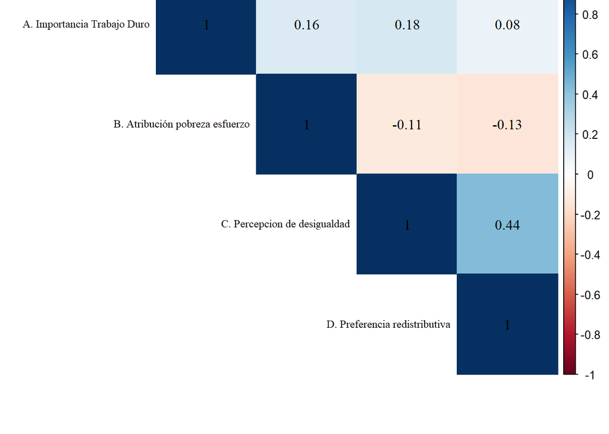

```r
library(corrplot)
est_proc$juicio_desigualdad <- set_na(est_proc$juicio_desigualdad, na = c(5,9), drop.levels = TRUE, as.tag = FALSE)

est_proc$atriv_pobr_esf <- set_na(est_proc$atriv_pobr_esf, na = c(5,9), drop.levels = TRUE, as.tag = FALSE)

est_proc$redistriv <- set_na(est_proc$redistriv, na = c(5,9), drop.levels = TRUE, as.tag = FALSE)


basecor <-  est_proc %>% select(perc_trabajo_duro,atriv_pobr_esf,juicio_desigualdad,redistriv)

basecor<-na.omit(basecor)

corest <- cor(basecor)


windowsFonts(A = windowsFont("Times New Roman"))
rownames(corest) <-c(
    "A. Importancia Trabajo Duro",
    "B. Atribución pobreza esfuerzo",
    "C. Percepcion de desigualdad",
    "D. Preferencia redistributiva")
colnames(corest) <-c("(A)", "(B)","(C)","(D)")

corplotest <-corrplot(corest, method = "color",
  type = "upper",
  tl.col = "black",
  addCoef.col = "black",
  diag = TRUE,
  family = "A",
  number.font = 6,
  tl.cex =0.75,
  number.cex = 1)
```

```r
stats::cor.test(basecor$perc_trabajo_duro,basecor$redistriv)
```

```
##
##  Pearson's product-moment correlation
##
## data:  basecor$perc_trabajo_duro and basecor$redistriv
## t = 3.2408, df = 1492, p-value = 0.001218
## alternative hypothesis: true correlation is not equal to 0
## 95 percent confidence interval:
##  0.03303294 0.13375575
## sample estimates:
##        cor
## 0.08360788
```

```r
library(corrplot)

ap_proc$juicio_desigualdad <- set_na(ap_proc$juicio_desigualdad, na = c(5,9), drop.levels = TRUE, as.tag = FALSE)

ap_proc$atriv_pobr_esf <- set_na(ap_proc$atriv_pobr_esf, na = c(5,9), drop.levels = TRUE, as.tag = FALSE)

ap_proc$redistriv <- set_na(ap_proc$redistriv, na = c(5,9), drop.levels = TRUE, as.tag = FALSE)

basecor <-  ap_proc %>% select(perc_trabajo_duro,atriv_pobr_esf,juicio_desigualdad,redistriv)
basecor<-na.omit(basecor)
basecor <- basecor[-1]

summary(basecor)
```

```
##  perc_trabajo_duro atriv_pobr_esf  juicio_desigualdad   redistriv
##  Min.   :1.000     Min.   :1.000   Min.   :1.00       Min.   :1.000
##  1st Qu.:3.000     1st Qu.:2.000   1st Qu.:3.00       1st Qu.:3.000
##  Median :3.000     Median :3.000   Median :4.00       Median :3.000
##  Mean   :3.221     Mean   :2.412   Mean   :3.61       Mean   :3.334
##  3rd Qu.:4.000     3rd Qu.:3.000   3rd Qu.:4.00       3rd Qu.:4.000
##  Max.   :4.000     Max.   :4.000   Max.   :4.00       Max.   :4.000
```

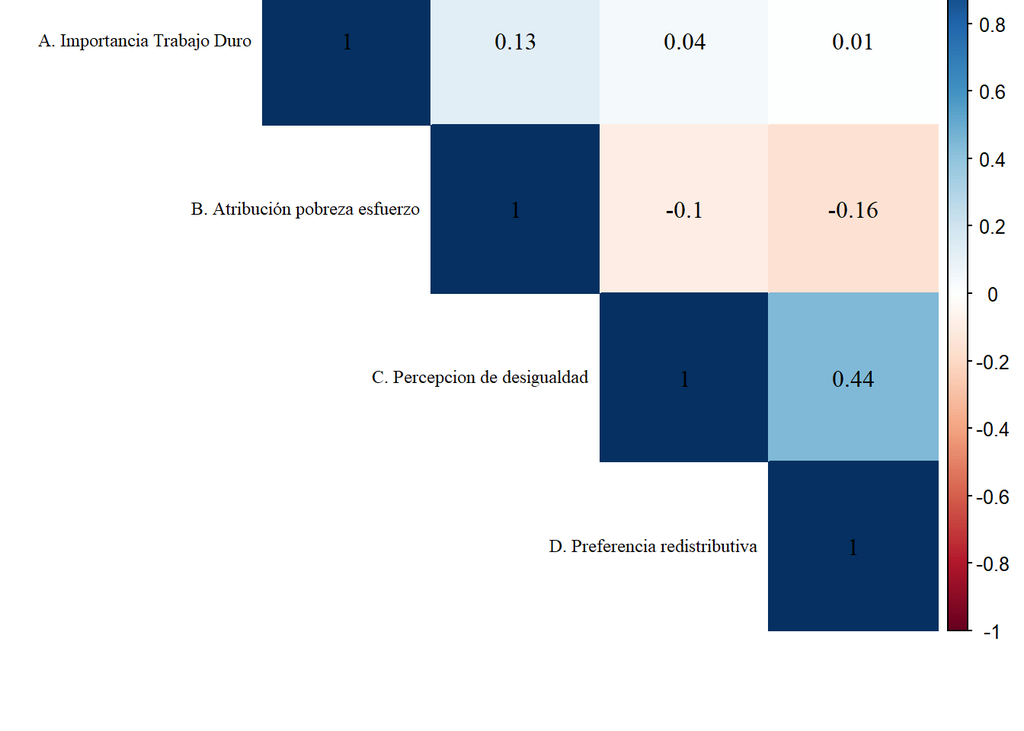

```r
corap<-cor(basecor)

windowsFonts(A = windowsFont("Times New Roman"))
rownames(corap) <-c(
    "A. Importancia Trabajo Duro",
    "B. Atribución pobreza esfuerzo",
    "C. Percepcion de desigualdad",
    "D. Preferencia redistributiva")
colnames(corap) <-c("(A)", "(B)","(C)","(D)")

corrplot(corap, method = "color",
  type = "upper",
  tl.col = "black",
  addCoef.col = "black",
  diag = TRUE,
  family = "A",
  number.font = 6,
  tl.cex =0.75,
  number.cex = 1)
```

```r
stats::cor.test(basecor$atriv_pobr_esf,basecor$juicio_desigualdad)
```

```
##
##  Pearson's product-moment correlation
##
## data:  basecor$atriv_pobr_esf and basecor$juicio_desigualdad
## t = -2.5145, df = 678, p-value = 0.01215
## alternative hypothesis: true correlation is not equal to 0
## 95 percent confidence interval:
##  -0.17007813 -0.02108893
## sample estimates:
##        cor
## -0.0961219
```

```r
library(ggplot2)
library(sjPlot)
#ggsave(plot_grid(list(corplotest,croplotapod),
#                 margin = c(0.5,0.5,0.5,0.5),
#                 tags = c(" ", " ")),
#       filename = "../output/results/relacion_meritequal.png", width = 10, height = 10, dpi= #"retina")
```

# trabajo de cuanti

```r
est_proc$educ <- set_na(est_proc$educ, na = c(5,9), drop.levels = TRUE, as.tag = FALSE)
est_proc$salud <- set_na(est_proc$salud, na = c(5,9), drop.levels = TRUE, as.tag = FALSE)


est_proc$redistriv <- set_na(est_proc$redistriv, na = c(5,9), drop.levels = TRUE, as.tag = FALSE)
est_proc$juicio_desigualdad <- set_na(est_proc$juicio_desigualdad, na = c(5,9), drop.levels = TRUE, as.tag = FALSE)

est_proc$cortes <- set_na(est_proc$cortes, na = c(5,9), drop.levels = TRUE, as.tag = FALSE)
est_proc$tomas <- set_na(est_proc$tomas, na = c(5,9), drop.levels = TRUE, as.tag = FALSE)

est_proc$atriv_pobr_esf <- set_na(est_proc$atriv_pobr_esf, na = c(5,9), drop.levels = TRUE, as.tag = FALSE)
est_proc$atriv_pobr_tal <- set_na(est_proc$atriv_pobr_tal, na = c(5,9), drop.levels = TRUE, as.tag = FALSE)


sjPlot::tab_xtab(var.row = est_proc$cortes, var.col = est_proc$redistriv, title = "Table Title", show.row.prc = TRUE, show.exp=T)
```

Table Title

| P35B La siguiente es una lista de acciones que las personas pueden realizar para | P25B ¿Cuán de acuerdo o en desacuerdo estás con las siguientes afirmaciones?ES R |  |  |  | Total |  |
| --- | --- | --- | --- | --- | --- | --- |
|  | Muy en desacuerdo | En desacuerdo | De acuerdo | Muy de acuerdo |  |  |
| Nunca se justifica | 36 12 17.6 % | 54 41 26.5 % | 80 95 39.2 % | 34 56 16.7 % |  | 204 204 100 % |
| Casi nunca se justifica | 20 22 5.4 % | 104 75 28.2 % | 190 172 51.5 % | 55 101 14.9 % | 369 369 100 % |  |
| A veces se justifica | 20 39 3 % | 119 135 17.8 % | 330 312 49.3 % | 200 183 29.9 % | 669 669 100 % |  |
| Siempre se justifica | 11 14 4.5 % | 24 50 9.7 % | 94 115 38.1 % | 118 68 47.8 % | 247 247 100 % |  |
| Total | 87 87 5.8 % | 301 301 20.2 % | 694 694 46.6 % | 407 407 27.3 % | 1489 1489 100 % |  |

```r
basecor<-  est_proc %>% select(redistriv, cortes)
psych::polychoric(basecor)
```

```
## Call: psych::polychoric(x = basecor)
## Polychoric correlations
##           rdstr corts
## redistriv 1.00
## cortes    0.33  1.00
##
##  with tau of
##              1     2    3
## redistriv -1.6 -0.64 0.59
## cortes    -1.1 -0.29 0.97
```

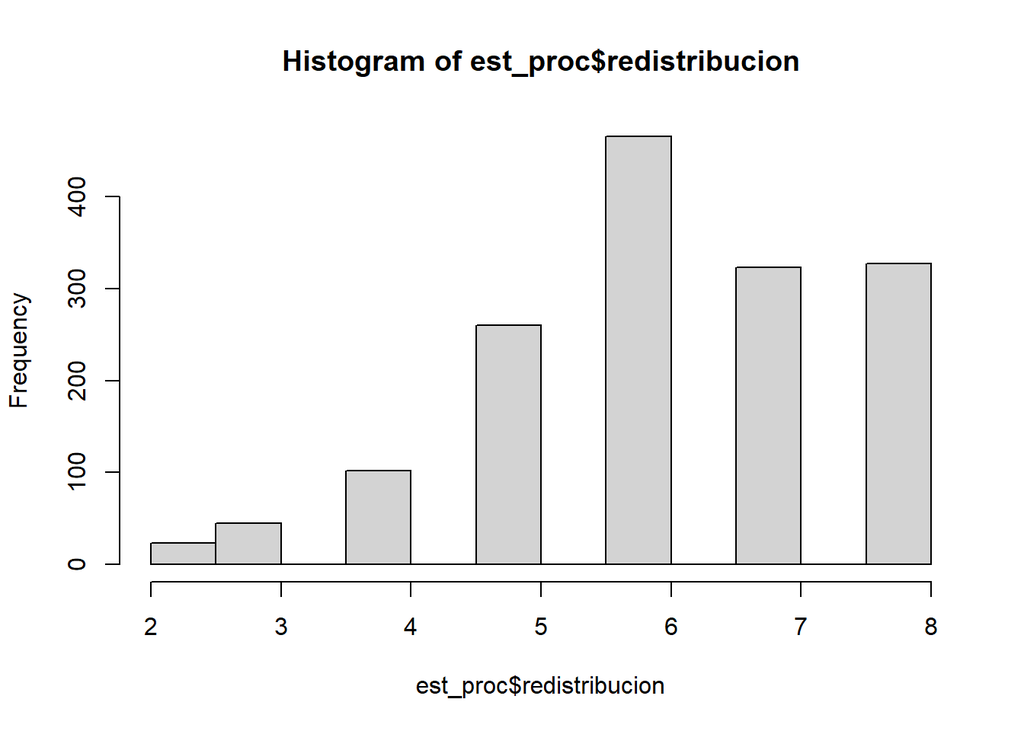

```r
est_proc$redistribucion<- as.numeric(est_proc$redistriv + est_proc$juicio_desigualdad)
hist(est_proc$redistribucion)
```

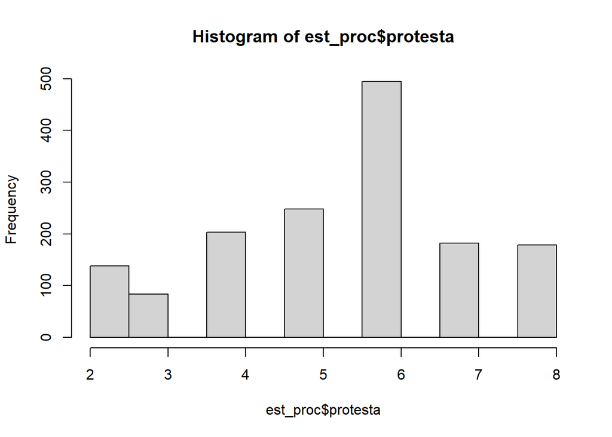

```r
est_proc$protesta<- as.numeric(est_proc$cortes + est_proc$tomas)
hist(est_proc$protesta)
```

```r
basecor<- est_proc %>% select(redistribucion, protesta)
basecor<-na.omit(basecor)
cor(basecor)
```

```
##                redistribucion  protesta
## redistribucion      1.0000000 0.2974101
## protesta            0.2974101 1.0000000
```

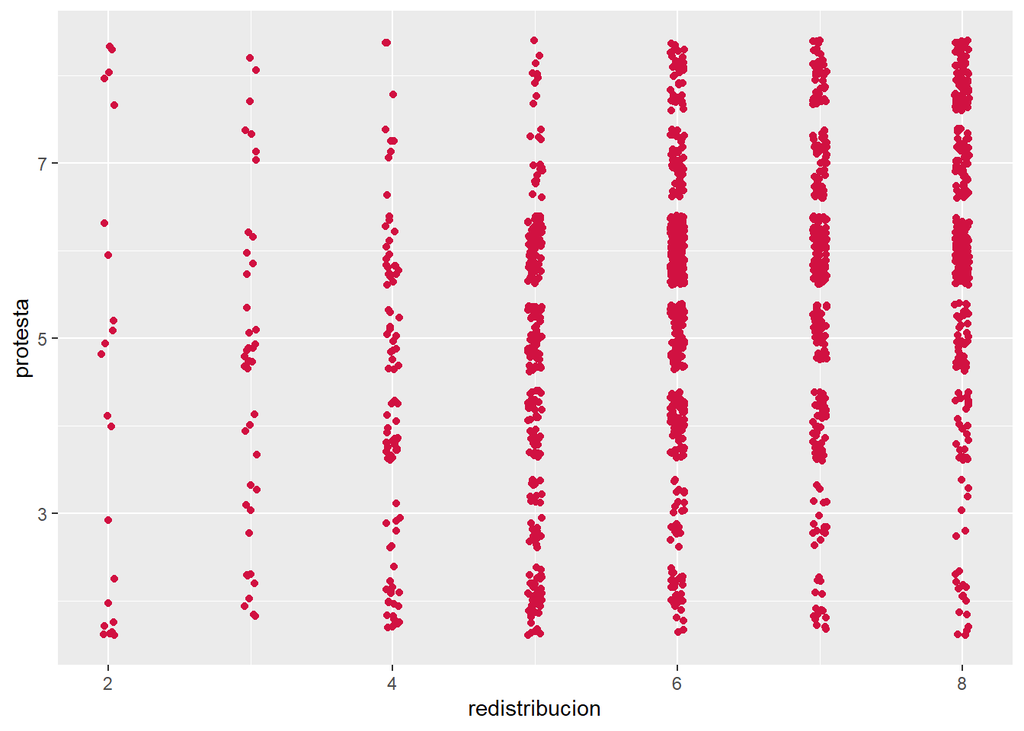

```r
plot_scatter(basecor, redistribucion, protesta)
```

### 1.2.2 Relacion redistrib.

```r
cfa_red1 <- '
    # latent variables
    redistribucion =~ redistriv + juicio_desigualdad
    protesta  =~ cortes + tomas
    '
```